# Football matches dataset

[figure not shown]

**Important tips when using this notebook**

Some charts/diagrams/features are not visible in github.

- This impacts all:
  - plotly plots
  - folium maps
  - embedded images
  - and all other dynamic content
  - quarto meta-tags that improves visualization

This is [standard and well-known behaviour](https://blog.jupyter.org/rendering-notebooks-on-github-f7ac8736d686).

- While some workarounds could be possible, there are no universal fixes that resolve **all** the issues.
  - Plotly customization [requires installing external tools](https://github.com/plotly/plotly.py/issues/931), but doesn't fix the other issues
  - Standard workarounds ([nbviewer](http://nbviewer.jupyter.org/)) do not work because the github repo is private.

# Recommendation? whenever possible, use the pre-rendered `.html` file

You have 2 options depending on how much you trust my code and how little time you want to dedicate to this review :)

1. ✅ open the prerendered HTML file, which contains all of the data without any of the rendering limitations that github suffers from
   - Best if you just want to review the analysis and conclusions You have two options for optimal viewing experience:
2. ✅ open the notebook in jupyterlab (instead of github) and re-run all cells
   - Best if you want to verify that the code works and that the data is not fake

# Requirements for running this locally: - you will need `python 3.9` - you will need to install the dependencies using `pip install -r requirements.txt` before proceeding.

# Context

For this dataset we want to explore different ways to predict match results to assist our ficticious betting company to enter this highly competitive market

# Exploratory Analysis

```python
import ipywidgets as widgets
from IPython.display import display, Markdown, Image, clear_output
import matplotlib.pyplot as plt

import duckdb
import numpy as np
import pandas as pd
import seaborn as sns
from scipy import stats
import statsmodels.api as sm
from tqdm import tqdm
import time
from collections import deque
from random import random, seed
import sqlite3 as lite
import logging
import warnings
import ydata_profiling
import iplantuml
import xml.dom.minidom

from sklearn.feature_selection import SelectKBest, f_regression
from sklearn.metrics import (
    ConfusionMatrixDisplay,
    accuracy_score,
    recall_score,
    precision_score,
)
from sklearn.preprocessing import MinMaxScaler, StandardScaler
from sklearn.decomposition import PCA
from sklearn.linear_model import LinearRegression, LogisticRegression

from utils import *
from utils import __
from football import *

from autofeat import AutoFeatRegressor as AFR
from sklearn.model_selection import train_test_split
from sklearn.exceptions import DataConversionWarning

seed(100)
pd.options.display.max_rows = 100
pd.options.display.max_colwidth = 50
util.check("done")
```

```
loading utils modules... ✅ completed
configuring autoreload... ✅ completed
loading football modules... ✅ completed
configuring autoreload... ✅ completed
✅
```

Let's use `black` to auto-format all our cells so they adhere to PEP8

```python
import lab_black

%reload_ext lab_black
util.patch_nb_black()
# fmt: off
# fmt: on
```

```python
logger = util.configure_logging(jupyterlab_level=logging.WARN, file_level=logging.DEBUG)

warnings.filterwarnings("ignore", category=FutureWarning)
```

## Fetching and loading the dataset

We're ready to start! Let's download the dataset from Kaggle.

```python
dataset_name = "prajitdatta/ultimate-25k-matches-football-database-european"
db_filename = "database.sqlite"

auto_kaggle.download_dataset(dataset_name, db_filename)
__
```

```
Kaggle API 1.5.13 - login as 'edualmas'
File [dataset/database.sqlite] already exists locally!
No need to re-download dataset [prajitdatta/ultimate-25k-matches-football-database-european]
```

```python
conn = lite.connect(f"dataset/{db_filename}")
sql = sql.Sql(conn)
cursor = conn.cursor()
table_names = sql.list_tables()
```

| table | rows |
| --- | --- |
| player_attributes | 183,978 |
| player | 11,060 |
| match | 25,979 |
| league | 11 |
| country | 11 |
| team | 299 |
| team_attributes | 1,458 |

the `player_attributes` table

|  | id | player_fifa_api_id | player_api_id | date | overall_rating | potential | preferred_foot | attacking_work_rate | defensive_work_rate | crossing | ... | vision | penalties | marking | standing_tackle | sliding_tackle | gk_diving | gk_handling | gk_kicking | gk_positioning | gk_reflexes |
| --- | --- | --- | --- | --- | --- | --- | --- | --- | --- | --- | --- | --- | --- | --- | --- | --- | --- | --- | --- | --- | --- |
| 0 | 1 | 218353 | 505942 | 2016-02-18 00:00:00 | 67 | 71 | right | medium | medium | 49 | ... | 54 | 48 | 65 | 69 | 69 | 6 | 11 | 10 | 8 | 8 |
| 1 | 2 | 218353 | 505942 | 2015-11-19 00:00:00 | 67 | 71 | right | medium | medium | 49 | ... | 54 | 48 | 65 | 69 | 69 | 6 | 11 | 10 | 8 | 8 |
| 2 | 3 | 218353 | 505942 | 2015-09-21 00:00:00 | 62 | 66 | right | medium | medium | 49 | ... | 54 | 48 | 65 | 66 | 69 | 6 | 11 | 10 | 8 | 8 |
| 3 | 4 | 218353 | 505942 | 2015-03-20 00:00:00 | 61 | 65 | right | medium | medium | 48 | ... | 53 | 47 | 62 | 63 | 66 | 5 | 10 | 9 | 7 | 7 |
| 4 | 5 | 218353 | 505942 | 2007-02-22 00:00:00 | 61 | 65 | right | medium | medium | 48 | ... | 53 | 47 | 62 | 63 | 66 | 5 | 10 | 9 | 7 | 7 |

5 rows × 42 columns

the `player` table

|  | id | player_api_id | player_name | player_fifa_api_id | birthday | height | weight |
| --- | --- | --- | --- | --- | --- | --- | --- |
| 0 | 1 | 505942 | Aaron Appindangoye | 218353 | 1992-02-29 00:00:00 | 182.88 | 187 |
| 1 | 2 | 155782 | Aaron Cresswell | 189615 | 1989-12-15 00:00:00 | 170.18 | 146 |
| 2 | 3 | 162549 | Aaron Doran | 186170 | 1991-05-13 00:00:00 | 170.18 | 163 |
| 3 | 4 | 30572 | Aaron Galindo | 140161 | 1982-05-08 00:00:00 | 182.88 | 198 |
| 4 | 5 | 23780 | Aaron Hughes | 17725 | 1979-11-08 00:00:00 | 182.88 | 154 |

the `match` table

|  | id | country_id | league_id | season | stage | date | match_api_id | home_team_api_id | away_team_api_id | home_team_goal | ... | SJA | VCH | VCD | VCA | GBH | GBD | GBA | BSH | BSD | BSA |
| --- | --- | --- | --- | --- | --- | --- | --- | --- | --- | --- | --- | --- | --- | --- | --- | --- | --- | --- | --- | --- | --- |
| 0 | 1 | 1 | 1 | 2008/2009 | 1 | 2008-08-17 00:00:00 | 492473 | 9987 | 9993 | 1 | ... | 4.00 | 1.65 | 3.40 | 4.50 | 1.78 | 3.25 | 4.00 | 1.73 | 3.40 | 4.20 |
| 1 | 2 | 1 | 1 | 2008/2009 | 1 | 2008-08-16 00:00:00 | 492474 | 10000 | 9994 | 0 | ... | 3.80 | 2.00 | 3.25 | 3.25 | 1.85 | 3.25 | 3.75 | 1.91 | 3.25 | 3.60 |
| 2 | 3 | 1 | 1 | 2008/2009 | 1 | 2008-08-16 00:00:00 | 492475 | 9984 | 8635 | 0 | ... | 2.50 | 2.35 | 3.25 | 2.65 | 2.50 | 3.20 | 2.50 | 2.30 | 3.20 | 2.75 |
| 3 | 4 | 1 | 1 | 2008/2009 | 1 | 2008-08-17 00:00:00 | 492476 | 9991 | 9998 | 5 | ... | 7.50 | 1.45 | 3.75 | 6.50 | 1.50 | 3.75 | 5.50 | 1.44 | 3.75 | 6.50 |
| 4 | 5 | 1 | 1 | 2008/2009 | 1 | 2008-08-16 00:00:00 | 492477 | 7947 | 9985 | 1 | ... | 1.73 | 4.50 | 3.40 | 1.65 | 4.50 | 3.50 | 1.65 | 4.75 | 3.30 | 1.67 |

5 rows × 115 columns

the `league` table

|  | id | country_id | name |
| --- | --- | --- | --- |
| 0 | 1 | 1 | Belgium Jupiler League |
| 1 | 1729 | 1729 | England Premier League |
| 2 | 4769 | 4769 | France Ligue 1 |
| 3 | 7809 | 7809 | Germany 1. Bundesliga |
| 4 | 10257 | 10257 | Italy Serie A |

the `country` table

|  | id | name |
| --- | --- | --- |
| 0 | 1 | Belgium |
| 1 | 1729 | England |
| 2 | 4769 | France |
| 3 | 7809 | Germany |
| 4 | 10257 | Italy |

the `team` table

|  | id | team_api_id | team_fifa_api_id | team_long_name | team_short_name |
| --- | --- | --- | --- | --- | --- |
| 0 | 1 | 9987 | 673 | KRC Genk | GEN |
| 1 | 2 | 9993 | 675 | Beerschot AC | BAC |
| 2 | 3 | 10000 | 15005 | SV Zulte-Waregem | ZUL |
| 3 | 4 | 9994 | 2007 | Sporting Lokeren | LOK |
| 4 | 5 | 9984 | 1750 | KSV Cercle Brugge | CEB |

the `team_attributes` table

|  | id | team_fifa_api_id | team_api_id | date | buildUpPlaySpeed | buildUpPlaySpeedClass | buildUpPlayDribbling | buildUpPlayDribblingClass | buildUpPlayPassing | buildUpPlayPassingClass | ... | chanceCreationShooting | chanceCreationShootingClass | chanceCreationPositioningClass | defencePressure | defencePressureClass | defenceAggression | defenceAggressionClass | defenceTeamWidth | defenceTeamWidthClass | defenceDefenderLineClass |
| --- | --- | --- | --- | --- | --- | --- | --- | --- | --- | --- | --- | --- | --- | --- | --- | --- | --- | --- | --- | --- | --- |
| 0 | 1 | 434 | 9930 | 2010-02-22 00:00:00 | 60 | Balanced | NaN | Little | 50 | Mixed | ... | 55 | Normal | Organised | 50 | Medium | 55 | Press | 45 | Normal | Cover |
| 1 | 2 | 434 | 9930 | 2014-09-19 00:00:00 | 52 | Balanced | 48.0 | Normal | 56 | Mixed | ... | 64 | Normal | Organised | 47 | Medium | 44 | Press | 54 | Normal | Cover |
| 2 | 3 | 434 | 9930 | 2015-09-10 00:00:00 | 47 | Balanced | 41.0 | Normal | 54 | Mixed | ... | 64 | Normal | Organised | 47 | Medium | 44 | Press | 54 | Normal | Cover |
| 3 | 4 | 77 | 8485 | 2010-02-22 00:00:00 | 70 | Fast | NaN | Little | 70 | Long | ... | 70 | Lots | Organised | 60 | Medium | 70 | Double | 70 | Wide | Cover |
| 4 | 5 | 77 | 8485 | 2011-02-22 00:00:00 | 47 | Balanced | NaN | Little | 52 | Mixed | ... | 52 | Normal | Organised | 47 | Medium | 47 | Press | 52 | Normal | Cover |

5 rows × 25 columns

The richest tables, in terms of data seem to be:

- player_attributes
- match
- team_attributes

The other tables only store data that will not help us achieve our goal

## Creating Custom Data Pipelines from scratch

For this project, I wanted to explore manipulating data using rudimentary (ie. hand-crafted) data pipelines.

I was inspired by this talk at [PyData Eindhoven 2019, by Vincent D. Warmerdam](https://www.youtube.com/watch?v=yXGCKqo5cEY&t=1110s) and wanted to iterate a bit over it.

I will try to give you a glimpse of how they operate, so you don't have to check the code (found in `utils/pipeline_utils.py`)

### Guiding principles

1. I want the notebook to show *WHAT* I am doing, and move the boring *HOW* to a separate module
2. If the "HOW I am doing something" is very relevant, I might leave it in the notebook to avoid forcing context switching on the reader
3. The Pipeline should be a stateful object that contains a dataframe and one method to apply transformations to it.
   1. The dataframe is taken in when the pipeline is created
   2. The operations are applied as steps which (might) mutate the dataframe
   3. The additional "property bag" is there so that some operations (that produce additional information) can store it there, for future retrieval
4. The Pipeline should also have additional methods to provide basic observability (see the current state of the data, which operations have been applied, in which order, how long each took to complete, etc...)
5. One pipeline can be cloned/forked into two, if needed, to avoid having to do common work multiple times.
   1. Upon cloning, the new pipeline retains all of the context from its parent pipeline (metadata: steps, property bag) and also retains a **copy** of the dataframe at that point in time.

Here's a small diagram to visualize how they work

```python
%%plantuml

@startuml
|matches pipeline|
start
:match_p = pipes.Pipeline(raw_match_df);
:match_p.step(remove_invalid_matches);
note right: custom cleaning function
:match_p.step(drop_columns, columns=cols);
note right: custom cleaning\n function w/ params
if (player_p = match_p.clone()) then (pipeline continues)
    |matches pipeline|
    :match_p.step(other_cleaning_step);
    :match_p.peek(plot_scatter_summary);
    note right: with `.peek()`, no transformation is applied,\nbut it allows inspecting/rendering the data in some way
    :match_p.step(another_operation);
    :match_p.df();
    note right: extract transformed\ndataframe after\nall processing steps
    end
else (a new pipeline is created)
    |players pipeline|
    :player_p.step(extract_players);
    :player_p.step(summarize_players);
    :player_p.step(create_player_model);
    :...;
    end
endif
@enduml
```

[figure not shown]

Now that we know how these pipelines work, we can get started.

## Understanding our dataset

One important thing to remember is that this data is extracted from the **EA Sports' FIFA video game series**, which raises questions:

- How was this data collected?
  - How are players assessed?
  - How is this data decided?
    - Is it measured? Is it derived from facts?
    - Is it decided by someone based on their observations?
    - Would different observers reach the same conclusions/results/attributes?
- These questions apply to the hardest to measure data (player attributes) but could also be asked about everything. e.g:
  - HOW are betting odds captured?
  - WHEN were they captured? (Some companies change their odds as the match progresses...)
  - etc...

Without a clear understanding of this, it will be hard to predict if our model could be improved:

- Someone's perception of a player's "attack strength" has little to contribute to the game result
- Actual facts (e.g. number of measured Kms that a player ran over the course of a match) might be an indicator of their actual potential to contribute to the final result (eg. could be an indicator of their stamina or athletic capabilities)

As the data is presented, we will be cautious and try not to take it too strictly.

We hope this caution will allow us to help us detect observer bias (Observer being: [FIFA](https://en.wikipedia.org/wiki/FIFA#Corruption), the creators of the data behind this dataset)

# Cleaning Data

## Cleaning `Player Attributes`

After this analyis we have found:

- **Important**: Nothing important to highlight
- **Interesting**: attacking_work_rate and defensive_work_rate are imbalanced towards the value "middle"

⬇ Expand for more info

```python
table_player_attributes = auto_pandas.from_sqlite("player_attributes", conn)
```

```
[auto_ndtypes] took 0.32s. {'shape': (183978, 42)}
[visualize_na] took 0.44s. {'shape': (183978, 42)}
```

```
<utils.pipeline_utils.Pipeline at 0x2a9bc2f0a90>
```

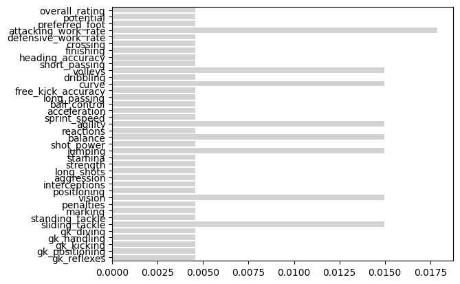

```python
player_attributes_p = pipes.Pipeline(table_player_attributes)
player_attributes_p.step(auto_pandas.auto_ndtypes)
player_attributes_p.step(cleaning.visualize_na)
```

```
[visualize_na_per_year] took 0.37s. {'shape': (183978, 42)}
```

```
<utils.pipeline_utils.Pipeline at 0x2a9bc2f0a90>
```

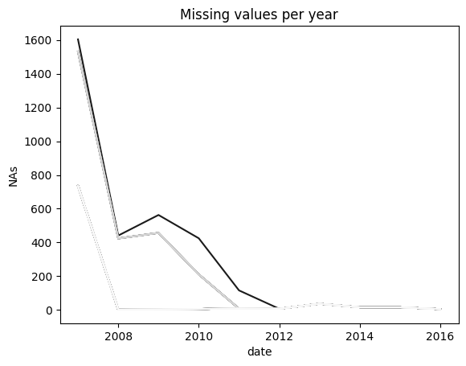

```python
player_attributes_p.step(cleaning.visualize_na_per_year)
```

A quick look at the data showed that there were entire rows with missing data, so we can drop them.

```python
player_attributes_p.step(cleaning.drop_NAs)
```

```
[drop_NAs] took 0.11s. {'shape': (180354, 42), 'shape_diff': '[-3624     0]'}
```

```
<utils.pipeline_utils.Pipeline at 0x2a9bc2f0a90>
```

```python
print(f"total NAs: {player_attributes_p.df().isna().sum().sum()}")
```

```
total NAs: 0
```

We can use also `ydata_profiling` to quickly assess how this dataframe looks.

```python
@run
@cached_profile_report()
def profile_player_attributes():
    return ydata_utils.report(player_attributes_p.df())
```

```
Loading from cache [./cached/profile_report/profile_player_attributes.html]
```

[interactive chart not shown]

## Cleaning `Match`

After this analyis we have found:

- **Important**: Nothing to highlight
- **Interesting**:
  - Data looks as expected and all of the warnings (60+) are reasonable and safe to ignore
  - We cannot use the XML fields to predict match results
    - The XML data fields contain lots of info, but we cannot use them for our model because we want to be able to predict results BEFORE the match starts... and we won't have those pieces of info (goals scored, red cards, etc... ) until the match is already underway

⬇ Expand for more info

```python
table_match = auto_pandas.from_sqlite("Match", conn)
```

```
[auto_ndtypes] took 0.25s. {'shape': (25979, 115)}
[drop_ps_bets] took 0.00s. {'shape': (25979, 112), 'shape_diff': '[ 0 -3]'}
[convert_player_ids_to_str] took 0.40s. {'shape': (25979, 112)}
[drop_columns_with_prefix] took 0.01s. {'shape': (25979, 101), 'shape_diff': '[  0 -11]'}
[drop_columns_with_prefix] took 0.01s. {'shape': (25979, 90), 'shape_diff': '[  0 -11]'}
[drop_xml_fields] took 0.01s. {'shape': (25979, 82), 'shape_diff': '[ 0 -8]'}
[visualize_na_per_year] took 0.22s. {'shape': (25979, 82)}
```

```
<utils.pipeline_utils.Pipeline at 0x2a9bf4e3130>
```

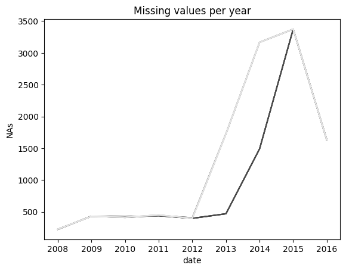

```python
match_p = pipes.Pipeline(table_match)


def drop_ps_bets(df):
    return df.drop(columns=["psh", "psa", "psd"])


(
    match_p.step(auto_pandas.auto_ndtypes)
    .step(drop_ps_bets)
    .step(cleaning.convert_player_ids_to_str)
    .step(cleaning.drop_columns_with_prefix, prefix="home_player_x")
    .step(cleaning.drop_columns_with_prefix, prefix="away_player_x")
    .step(cleaning.drop_xml_fields)
    .step(cleaning.visualize_na_per_year, min_nas=1000)
)
```

```python
match_without_bets = match_p.clone()
match_without_bets.step(cleaning.drop_betting_companies)
```

```
[drop_betting_companies] took 0.01s. {'shape': (25979, 55), 'shape_diff': '[  0 -27]'}
```

```
<utils.pipeline_utils.Pipeline at 0x2a9bf486f10>
```

```python
@run
@cached_profile_report()
def profile_match_without_betting_companies():
    return ydata_utils.report(match_without_bets.df())
```

```
Loading from cache [./cached/profile_report/profile_match_without_betting_companies.html]
```

[interactive chart not shown]

## Removing matches with missing data

For this next part we want to understand the meaning of missing match data.

For player data that is missing:

- is it a bug (a data problem that could be solved by improving the data collection methodology)?
- or is it intentional (does it model the real world correctly)?

Specifically, we want to understand what happens when a match has missing data for one or more of its players.

- If there is a data bug (missing data cannot be explained), we will have to drop those.
- If the missing data represents the world correctly (eg. a player got a red card and got kicked out), we might want to include it into our prediction model so it takes it into account.

We will try to find matches that are missing data for players that is **not explainable through player expulsions** (after receiving 🟨+🟨 2 yellow cards or 🟥 1 red card).

```python
players_per_match = match_p.df().groupby("match_api_id").count()[["date"]]
players_per_match = players_per_match.rename(columns={"date": "player_count"})
```

```python
players_per_match_str = players_per_match.reset_index()
players_per_match_str["match_api_id"] = players_per_match_str["match_api_id"].astype(
    "str"
)
```

```python
match_cards = table_match.copy()
match_cards["match_api_id"] = match_cards["match_api_id"].astype("str")
match_cards
```

|  | id | country_id | league_id | season | stage | date | match_api_id | home_team_api_id | away_team_api_id | home_team_goal | ... | sja | vch | vcd | vca | gbh | gbd | gba | bsh | bsd | bsa |
| --- | --- | --- | --- | --- | --- | --- | --- | --- | --- | --- | --- | --- | --- | --- | --- | --- | --- | --- | --- | --- | --- |
| 0 | 1 | 1 | 1 | 2008/2009 | 1 | 2008-08-17 | 492473 | 9987 | 9993 | 1 | ... | 4.0 | 1.65 | 3.4 | 4.5 | 1.78 | 3.25 | 4.0 | 1.73 | 3.4 | 4.2 |
| 1 | 2 | 1 | 1 | 2008/2009 | 1 | 2008-08-16 | 492474 | 10000 | 9994 | 0 | ... | 3.8 | 2.0 | 3.25 | 3.25 | 1.85 | 3.25 | 3.75 | 1.91 | 3.25 | 3.6 |
| 2 | 3 | 1 | 1 | 2008/2009 | 1 | 2008-08-16 | 492475 | 9984 | 8635 | 0 | ... | 2.5 | 2.35 | 3.25 | 2.65 | 2.5 | 3.2 | 2.5 | 2.3 | 3.2 | 2.75 |
| 3 | 4 | 1 | 1 | 2008/2009 | 1 | 2008-08-17 | 492476 | 9991 | 9998 | 5 | ... | 7.5 | 1.45 | 3.75 | 6.5 | 1.5 | 3.75 | 5.5 | 1.44 | 3.75 | 6.5 |
| 4 | 5 | 1 | 1 | 2008/2009 | 1 | 2008-08-16 | 492477 | 7947 | 9985 | 1 | ... | 1.73 | 4.5 | 3.4 | 1.65 | 4.5 | 3.5 | 1.65 | 4.75 | 3.3 | 1.67 |
| ... | ... | ... | ... | ... | ... | ... | ... | ... | ... | ... | ... | ... | ... | ... | ... | ... | ... | ... | ... | ... | ... |
| 25974 | 25975 | 24558 | 24558 | 2015/2016 | 9 | 2015-09-22 | 1992091 | 10190 | 10191 | 1 | ... | <NA> | <NA> | <NA> | <NA> | <NA> | <NA> | <NA> | <NA> | <NA> | <NA> |
| 25975 | 25976 | 24558 | 24558 | 2015/2016 | 9 | 2015-09-23 | 1992092 | 9824 | 10199 | 1 | ... | <NA> | <NA> | <NA> | <NA> | <NA> | <NA> | <NA> | <NA> | <NA> | <NA> |
| 25976 | 25977 | 24558 | 24558 | 2015/2016 | 9 | 2015-09-23 | 1992093 | 9956 | 10179 | 2 | ... | <NA> | <NA> | <NA> | <NA> | <NA> | <NA> | <NA> | <NA> | <NA> | <NA> |
| 25977 | 25978 | 24558 | 24558 | 2015/2016 | 9 | 2015-09-22 | 1992094 | 7896 | 10243 | 0 | ... | <NA> | <NA> | <NA> | <NA> | <NA> | <NA> | <NA> | <NA> | <NA> | <NA> |
| 25978 | 25979 | 24558 | 24558 | 2015/2016 | 9 | 2015-09-23 | 1992095 | 10192 | 9931 | 4 | ... | <NA> | <NA> | <NA> | <NA> | <NA> | <NA> | <NA> | <NA> | <NA> | <NA> |

25979 rows × 115 columns

```python
players_per_match_str = pd.merge(
    left=players_per_match_str, right=match_cards, on="match_api_id"
)

del match_cards
```

```python
players_per_match_str
```

|  | match_api_id | player_count | id | country_id | league_id | season | stage | date | home_team_api_id | away_team_api_id | ... | sja | vch | vcd | vca | gbh | gbd | gba | bsh | bsd | bsa |
| --- | --- | --- | --- | --- | --- | --- | --- | --- | --- | --- | --- | --- | --- | --- | --- | --- | --- | --- | --- | --- | --- |
| 0 | 1002982 | 1 | 20312 | 19694 | 19694 | 2010/2011 | 34 | 2011-04-24 | 8548 | 9925 | ... | 2.75 | 2.5 | 3.3 | 2.75 | 2.35 | 3.25 | 2.75 | 2.4 | 3.3 | 2.8 |
| 1 | 1005014 | 1 | 20313 | 19694 | 19694 | 2010/2011 | 34 | 2011-04-23 | 9938 | 8597 | ... | 3.5 | 1.95 | 3.5 | 4.0 | 1.9 | 3.4 | 3.6 | 1.85 | 3.4 | 3.8 |
| 2 | 1005015 | 1 | 20314 | 19694 | 19694 | 2010/2011 | 34 | 2011-04-23 | 9860 | 9927 | ... | 4.5 | 1.83 | 3.5 | 4.33 | 1.75 | 3.4 | 4.25 | 1.73 | 3.5 | 4.5 |
| 3 | 1005016 | 1 | 20315 | 19694 | 19694 | 2010/2011 | 34 | 2011-04-24 | 10251 | 9800 | ... | 4.0 | 1.83 | 3.5 | 4.33 | 1.75 | 3.4 | 4.25 | 1.73 | 3.5 | 4.5 |
| 4 | 1005017 | 1 | 20316 | 19694 | 19694 | 2010/2011 | 34 | 2011-04-25 | 8467 | 8066 | ... | 2.63 | 2.5 | 3.3 | 2.75 | 2.4 | 3.25 | 2.65 | 2.38 | 3.25 | 2.75 |
| ... | ... | ... | ... | ... | ... | ... | ... | ... | ... | ... | ... | ... | ... | ... | ... | ... | ... | ... | ... | ... | ... |
| 25974 | 954551 | 1 | 25063 | 24558 | 24558 | 2010/2011 | 36 | 2011-05-25 | 9931 | 10199 | ... | <NA> | <NA> | <NA> | <NA> | <NA> | <NA> | <NA> | <NA> | <NA> | <NA> |
| 25975 | 954552 | 1 | 25064 | 24558 | 24558 | 2010/2011 | 36 | 2011-05-25 | 6493 | 9956 | ... | <NA> | <NA> | <NA> | <NA> | <NA> | <NA> | <NA> | <NA> | <NA> | <NA> |
| 25976 | 954553 | 1 | 25065 | 24558 | 24558 | 2010/2011 | 36 | 2011-05-25 | 10179 | 7955 | ... | <NA> | <NA> | <NA> | <NA> | <NA> | <NA> | <NA> | <NA> | <NA> | <NA> |
| 25977 | 954554 | 1 | 25066 | 24558 | 24558 | 2010/2011 | 36 | 2011-05-25 | 10192 | 10190 | ... | <NA> | <NA> | <NA> | <NA> | <NA> | <NA> | <NA> | <NA> | <NA> | <NA> |
| 25978 | 954555 | 1 | 25067 | 24558 | 24558 | 2010/2011 | 36 | 2011-05-25 | 10243 | 10191 | ... | <NA> | <NA> | <NA> | <NA> | <NA> | <NA> | <NA> | <NA> | <NA> | <NA> |

25979 rows × 116 columns

```python
players_per_match_str["missing_players"] = (
    players_per_match_str[football.columns_for(["home_player_", "away_player_"])]
    .isna()
    .sum(axis=1)
)
```

```python
players_per_match_str[players_per_match_str["missing_players"] > 0].sort_values(
    by="missing_players", ascending=False
)
```

|  | match_api_id | player_count | id | country_id | league_id | season | stage | date | home_team_api_id | away_team_api_id | ... | vch | vcd | vca | gbh | gbd | gba | bsh | bsd | bsa | missing_players |
| --- | --- | --- | --- | --- | --- | --- | --- | --- | --- | --- | --- | --- | --- | --- | --- | --- | --- | --- | --- | --- | --- |
| 17855 | 506527 | 1 | 15740 | 15722 | 15722 | 2008/2009 | 11 | 2008-11-02 | 1957 | 2186 | ... | <NA> | <NA> | <NA> | <NA> | <NA> | <NA> | <NA> | <NA> | <NA> | 22 |
| 17417 | 492851 | 1 | 114 | 1 | 1 | 2008/2009 | 20 | 2009-01-31 | 10000 | 8203 | ... | 1.85 | 3.25 | 3.75 | 1.8 | 3.3 | 4.25 | 1.75 | 3.3 | 4.2 | 22 |
| 17427 | 492995 | 1 | 124 | 1 | 1 | 2008/2009 | 21 | 2009-02-07 | 4049 | 8203 | ... | 2.4 | 3.25 | 2.6 | 2.4 | 3.2 | 2.75 | 2.38 | 3.2 | 2.62 | 22 |
| 17426 | 492994 | 1 | 123 | 1 | 1 | 2008/2009 | 21 | 2009-02-08 | 10001 | 9994 | ... | 1.9 | 3.25 | 3.6 | 2.0 | 3.25 | 3.5 | 2.0 | 3.2 | 3.4 | 22 |
| 17425 | 492993 | 1 | 122 | 1 | 1 | 2008/2009 | 21 | 2009-02-08 | 9984 | 9986 | ... | 1.6 | 3.4 | 5.0 | 1.6 | 3.5 | 5.5 | 1.57 | 3.5 | 5.5 | 22 |
| ... | ... | ... | ... | ... | ... | ... | ... | ... | ... | ... | ... | ... | ... | ... | ... | ... | ... | ... | ... | ... | ... |
| 14713 | 1994778 | 1 | 17509 | 15722 | 15722 | 2015/2016 | 21 | 2015-12-18 | 8021 | 8020 | ... | <NA> | <NA> | <NA> | <NA> | <NA> | <NA> | <NA> | <NA> | <NA> | 1 |
| 14740 | 1994805 | 1 | 17536 | 15722 | 15722 | 2015/2016 | 24 | 2016-02-26 | 8025 | 8020 | ... | <NA> | <NA> | <NA> | <NA> | <NA> | <NA> | <NA> | <NA> | <NA> | 1 |
| 14742 | 1994807 | 1 | 17538 | 15722 | 15722 | 2015/2016 | 25 | 2016-03-02 | 1957 | 8023 | ... | <NA> | <NA> | <NA> | <NA> | <NA> | <NA> | <NA> | <NA> | <NA> | 1 |
| 14744 | 1994809 | 1 | 17540 | 15722 | 15722 | 2015/2016 | 25 | 2016-03-08 | 8028 | 8025 | ... | <NA> | <NA> | <NA> | <NA> | <NA> | <NA> | <NA> | <NA> | <NA> | 1 |
| 25974 | 954551 | 1 | 25063 | 24558 | 24558 | 2010/2011 | 36 | 2011-05-25 | 9931 | 10199 | ... | <NA> | <NA> | <NA> | <NA> | <NA> | <NA> | <NA> | <NA> | <NA> | 1 |

4605 rows × 117 columns

```python
players_per_match_str[
    (players_per_match_str["missing_players"] > 0)
    & (~players_per_match_str.card.isna())
    & (players_per_match_str.card.str.len() < 120)
]
```

|  | match_api_id | player_count | id | country_id | league_id | season | stage | date | home_team_api_id | away_team_api_id | ... | vch | vcd | vca | gbh | gbd | gba | bsh | bsd | bsa | missing_players |
| --- | --- | --- | --- | --- | --- | --- | --- | --- | --- | --- | --- | --- | --- | --- | --- | --- | --- | --- | --- | --- | --- |
| 223 | 1019770 | 1 | 6032 | 4769 | 4769 | 2011/2012 | 20 | 2012-01-14 | 7819 | 9851 | ... | 3.0 | 3.1 | 2.4 | 2.85 | 3.1 | 2.4 | 2.88 | 3.1 | 2.5 | 1 |
| 685 | 1024726 | 1 | 2889 | 1729 | 1729 | 2011/2012 | 11 | 2011-11-05 | 9825 | 8659 | ... | 1.4 | 5.0 | 8.5 | 1.4 | 4.33 | 7.5 | 1.4 | 4.5 | 8.0 | 1 |
| 825 | 1025305 | 1 | 3016 | 1729 | 1729 | 2011/2012 | 22 | 2012-01-21 | 10194 | 8659 | ... | 2.0 | 3.5 | 4.2 | 1.9 | 3.3 | 4.0 | 1.83 | 3.5 | 4.33 | 1 |
| 932 | 1025929 | 1 | 3133 | 1729 | 1729 | 2011/2012 | 33 | 2012-04-11 | 8456 | 8659 | ... | 1.25 | 6.25 | 15.0 | 1.22 | 6.0 | 11.0 | 1.29 | 5.0 | 11.0 | 1 |
| 6786 | 1468195 | 1 | 6995 | 4769 | 4769 | 2013/2014 | 4 | 2013-08-31 | 9837 | 9830 | ... | 2.25 | 3.2 | 3.6 | <NA> | <NA> | <NA> | <NA> | <NA> | <NA> | 1 |
| 9725 | 1709880 | 1 | 7152 | 4769 | 4769 | 2014/2015 | 19 | 2014-12-20 | 8689 | 9830 | ... | 2.38 | 3.1 | 3.5 | <NA> | <NA> | <NA> | <NA> | <NA> | <NA> | 1 |
| 12410 | 1778368 | 1 | 24072 | 21518 | 21518 | 2014/2015 | 34 | 2015-04-28 | 8634 | 8305 | ... | 1.03 | 23.0 | 67.0 | <NA> | <NA> | <NA> | <NA> | <NA> | <NA> | 1 |
| 13264 | 1983429 | 1 | 15501 | 13274 | 13274 | 2015/2016 | 18 | 2016-01-16 | 8526 | 10218 | ... | 2.38 | 3.6 | 2.88 | <NA> | <NA> | <NA> | <NA> | <NA> | <NA> | 1 |
| 13435 | 1987599 | 1 | 4701 | 1729 | 1729 | 2015/2016 | 38 | 2016-05-15 | 8668 | 9850 | ... | 1.8 | 3.9 | 4.6 | <NA> | <NA> | <NA> | <NA> | <NA> | <NA> | 1 |
| 17644 | 499414 | 1 | 7834 | 7809 | 7809 | 2008/2009 | 11 | 2008-11-02 | 9788 | 9810 | ... | 2.0 | 3.3 | 3.2 | 2.1 | 3.2 | 3.3 | 2.0 | 3.25 | 3.4 | 3 |
| 17656 | 499426 | 1 | 7846 | 7809 | 7809 | 2008/2009 | 13 | 2008-11-15 | 9789 | 9810 | ... | 1.6 | 3.8 | 5.0 | 1.7 | 3.6 | 5.0 | 1.67 | 3.5 | 4.75 | 1 |
| 17782 | 499552 | 1 | 7981 | 7809 | 7809 | 2008/2009 | 27 | 2009-04-12 | 8178 | 8697 | ... | 2.35 | 3.4 | 2.75 | 2.4 | 3.25 | 2.85 | 2.25 | 3.4 | 2.88 | 1 |
| 18672 | 530116 | 1 | 21841 | 21518 | 21518 | 2008/2009 | 4 | 2008-09-24 | 8633 | 9869 | ... | 1.14 | 6.5 | 13.0 | 1.17 | 6.0 | 14.0 | 1.17 | 6.5 | 13.0 | 2 |
| 18703 | 530207 | 1 | 21872 | 21518 | 21518 | 2008/2009 | 7 | 2008-10-19 | 10267 | 8388 | ... | 1.3 | 4.35 | 9.5 | 1.35 | 4.2 | 9.0 | 1.33 | 4.5 | 8.5 | 2 |
| 18828 | 530452 | 1 | 21627 | 21518 | 21518 | 2008/2009 | 19 | 2009-01-18 | 10205 | 8661 | ... | 1.45 | 3.6 | 7.0 | 1.47 | 4.0 | 7.5 | 1.44 | 4.0 | 7.5 | 1 |
| 20423 | 659145 | 1 | 2375 | 1729 | 1729 | 2009/2010 | 33 | 2010-04-03 | 8191 | 8456 | ... | 5.5 | 3.75 | 1.67 | 4.75 | 3.5 | 1.73 | 4.5 | 3.6 | 1.73 | 1 |
| 21650 | 684609 | 1 | 22119 | 21518 | 21518 | 2009/2010 | 3 | 2009-09-20 | 8633 | 9868 | ... | 1.12 | 7.0 | 15.0 | 1.12 | 8.0 | 16.0 | 1.12 | 7.0 | 17.0 | 1 |
| 21673 | 684651 | 1 | 22232 | 21518 | 21518 | 2009/2010 | 5 | 2009-09-27 | 8661 | 10281 | ... | 1.75 | 3.3 | 4.33 | 1.85 | 3.5 | 4.0 | 1.91 | 3.3 | 3.6 | 1 |
| 22000 | 685201 | 1 | 22209 | 21518 | 21518 | 2009/2010 | 38 | 2010-05-16 | 8696 | 9869 | ... | 1.25 | 5.5 | 10.0 | 1.3 | 5.0 | 9.0 | 1.3 | 4.75 | 10.0 | 1 |
| 22007 | 685210 | 1 | 22216 | 21518 | 21518 | 2009/2010 | 38 | 2010-05-15 | 8315 | 9783 | ... | 1.8 | 3.6 | 4.0 | 1.75 | 3.5 | 4.5 | 1.75 | 3.5 | 4.33 | 2 |
| 24151 | 840085 | 1 | 2649 | 1729 | 1729 | 2010/2011 | 24 | 2011-01-22 | 10260 | 8658 | ... | 1.2 | 7.0 | 17.0 | 1.2 | 6.0 | 13.0 | 1.2 | 6.0 | 15.0 | 1 |
| 25157 | 875487 | 1 | 22586 | 21518 | 21518 | 2010/2011 | 37 | 2011-05-15 | 9869 | 8696 | ... | 1.3 | 5.25 | 9.0 | 1.35 | 4.75 | 8.0 | 1.33 | 4.75 | 7.5 | 1 |

22 rows × 117 columns

```python
players_per_match_str[players_per_match_str.match_api_id == "499414"][
    football.columns_for(["home_player_", "away_player_"])
].T
```

|  | 17644 |
| --- | --- |
| home_player_1 | <NA> |
| home_player_2 | 36380 |
| home_player_3 | 36390 |
| home_player_4 | 27412 |
| home_player_5 | <NA> |
| home_player_6 | <NA> |
| home_player_7 | 14533 |
| home_player_8 | 29257 |
| home_player_9 | 27306 |
| home_player_10 | 71353 |
| home_player_11 | 31936 |
| away_player_1 | 27467 |
| away_player_2 | 27472 |
| away_player_3 | 27475 |
| away_player_4 | 30572 |
| away_player_5 | 30912 |
| away_player_6 | 36060 |
| away_player_7 | 41923 |
| away_player_8 | 95088 |
| away_player_9 | 41931 |
| away_player_10 | 69864 |
| away_player_11 | 37760 |

Let's find games that have card information (yellow/red cards issued to players)

````python
def pretty_print_xml(s: str):
    dom = xml.dom.minidom.parseString(s)
    pretty_xml_as_string = dom.toprettyxml()
    display(Markdown("```xml\n" + pretty_xml_as_string + "\n```"))
````

```python
def cards_for_match(match_id):
    df = players_per_match_str
    return df[df["match_api_id"] == match_id].card.iloc[0]


pretty_print_xml(cards_for_match("499414"))
```

```
<?xml version="1.0" ?>
<card/>
```

So, we've found various cases (match id = "499414" is just one example) that have:

- players that are missing
- information about cards issued during the match
- the info about the cards does not tell us they were kicked out of the game

We can also see other examples:

- match 489055 (shows 1 red card, but the player still appears in dataframe)
- match 489046 (shows no red cards, still 1 player missing)
- etc...

**We conclude that some of these data is missing data** but it doesn't affect too many matches, so **we will drop them**

# Understanding our data

## Understanding the leagues

|  | country | league | total_goals |
| --- | --- | --- | --- |
| 0 | Spain | Spain LIGA BBVA | 8412 |
| 1 | England | England Premier League | 8240 |
| 2 | Italy | Italy Serie A | 7895 |
| 3 | Netherlands | Netherlands Eredivisie | 7542 |
| 4 | France | France Ligue 1 | 7427 |
| 5 | Germany | Germany 1. Bundesliga | 7103 |
| 6 | Portugal | Portugal Liga ZON Sagres | 5201 |
| 7 | Belgium | Belgium Jupiler League | 4841 |
| 8 | Scotland | Scotland Premier League | 4804 |
| 9 | Poland | Poland Ekstraklasa | 4656 |
| 10 | Switzerland | Switzerland Super League | 4166 |

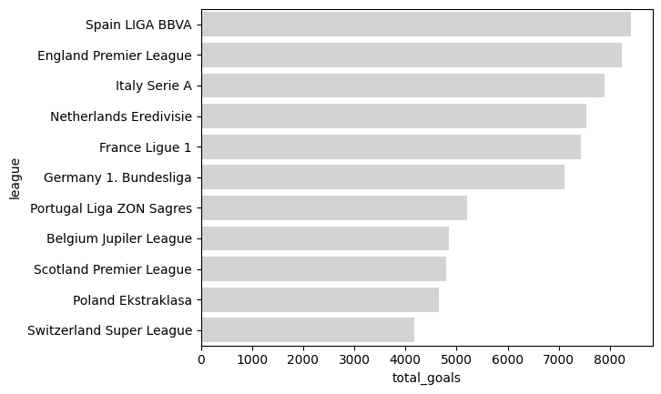

```python
@run
def country_league():
    alpha = 0.05
    q = """
    SELECT c.name, l.name as league, sum(home_team_goal) + sum(away_team_goal) total_goals
    FROM match m
        LEFT JOIN league l ON m.league_id = l.country_id
        INNER JOIN country c ON c.id = l.country_id
    GROUP BY l.name
    ORDER BY total_goals DESC;
    """
    df: DataFrame = sql.query(q)
    df.columns = ["country", "league", "total_goals"]
    sns.barplot(data=df, y="league", x="total_goals", orient="h", color="lightgrey")
    return df
```

## Understanding goals distribution per league/country

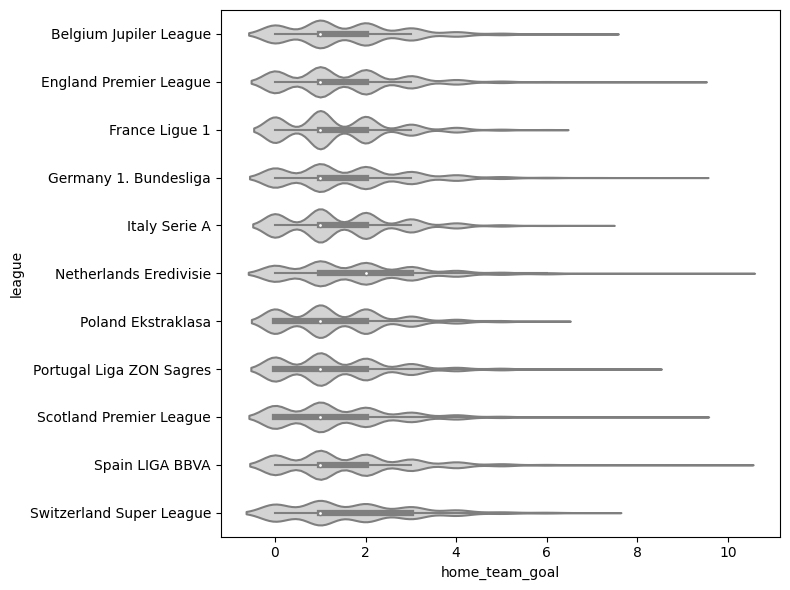

```python
@run
@cached_chart()
def render_goals_by_country():
    alpha = 0.05
    q = """
    SELECT l.name as league, home_team_goal, away_team_goal
    FROM match m
        LEFT JOIN league l ON m.league_id = l.country_id;
    """

    plt.figure(figsize=(8, 6))
    return sns.violinplot(
        data=sql.query(q), y="league", x="home_team_goal", color="lightgrey"
    )
```

## Understanding home team advantage

```
Loading from cache [./cached/charts/home_advantage.png]
```

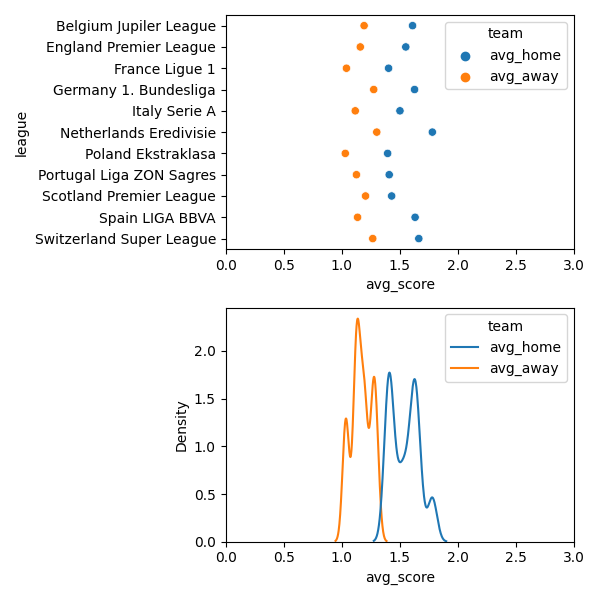

```python
@run
@cached_chart()
def home_advantage():
    alpha = 0.05
    q = """
    SELECT l.name as league, avg(home_team_goal) as avg_home, avg(away_team_goal) as avg_away
    FROM match m
        LEFT JOIN league l ON m.league_id = l.country_id
    GROUP BY l.name;
    """
    df: DataFrame = sql.query(q)
    stat, pval = stats.ttest_ind(df["avg_home"], df["avg_away"])
    if pval < alpha:
        print("these two samples are statistically significantly different")
        print(f"p-val = {pval:.8f}")

    df = df.melt(
        id_vars="league",
        value_vars=["avg_home", "avg_away"],
        var_name="team",
        value_name="avg_score",
    )
    f, ax = plt.subplots(2, 1, figsize=(6, 6))
    sns.scatterplot(data=df, y="league", x="avg_score", hue="team", ax=ax[0])
    sns.kdeplot(data=df, x="avg_score", hue="team", ax=ax[1], bw_adjust=0.5)
    ax[0].set_xlim(0, 3)
    ax[1].set_xlim(0, 3)
    return f
```

It seems that, when splitting by country/league, there is a clear difference between home goals and away goals. In later analyses we will see that this difference keeps reappearing in different slicings of the data, allowing us to conclude that "home team advantage" seems to be a real thing.

The difference in scores is so small that it keeps the matches more interesting than if it was much larger.

# Predicting outcomes of football matches

We want to predict the match outcome (win/no-win), and we will try different approaches:

- Linear models
  1. Using linear regression, we can try to predict the `home_team_goal_advantage` (difference in goals between the two teams)
     - We expect that the magnitude of the prediction will be useful to understand the model's "confidence" in the predicted result
  2. Using logistic regression, we can try to predict the `home_team_win` (the win/no-win for the home team).
- Non Linear models
  1. Using non-linear models, we can try to generate new non-linear features that might give us better results.
- Statistical models
  1. Using simple statistical models, we can try to predict likelihood of different results, and from there, derive the predicted win/no-win result

## Modelling matches

We want to build a model that can predict match results.

This will require considerable data wrangling, as we have to process, join and aggregate data from various places.

The end goal is to have something that looks like this:

- on each row, 1 match
- columns for all combinations of:
  - team (home/away)
  - position (goalie, defense, midfielder, forward)
  - attribute (all of them: speed, strength, dive, pass, ...)
- maybe columns for some derived features:
  - e.g. `away_forward_advantage = away_forward_strength - (home_defense_strength + home_goalie_strength)`
    - how likely is the *away team* to overpower the *home team*'s defense?)
- one target column `home_team_goal_advantage` to predict the result of the match (winner and by how much)
  - we can then use the magnitude of the prediction as a measure of the model's confidence in the team winning/losing (so that, if it ends up predicting a win by 6 points = very confident of a win)

| date | home_defense_strength | home_defense_speed | home_midfielder_speed | .. | home_goalkeeper_dive | .. | away_defense_strength | away_defense_strength | away_forward_speed | ... | ... | score_difference (home team advantage) |
| --- | --- | --- | --- | --- | --- | --- | --- | --- | --- | --- | --- | --- |
| 2020-01-01 | 45 | 90 | 45 | .. | nn | .. | .. | .. | .. | .. | .. | 0 (tie) |
| 2020-01-01 | 37 | 91 | 76 | .. | nn | .. | .. | .. | .. | .. | .. | -2 (away team won by 2) |

We want to be able to use this to predict match winners

```python
def select_player_columns(df):
    columns = ["match_api_id", "date"]
    player_prefixes = ["away_player_", "home_player_", "away_player_y", "home_player_y"]
    columns.extend(columns_for(player_prefixes))
    return df[columns]


match_summary = match_p.clone()
match_summary.step(select_player_columns)
match_summary.step(cleaning.cast_date_col)
match_summary.step(cleaning.drop_NAs)
match_players = match_summary.clone()
match_summary.step(munge.melt_match_players)
match_summary.step(
    munge.enrich_with_player_info, player_attributes=player_attributes_p.df()
)
match_summary.peek_df().peek_describe()
```

```
[select_player_columns] took 0.01s. {'shape': (25979, 46), 'shape_diff': '[  0 -36]'}
[cast_date_col] took 0.01s. {'shape': (25979, 46)}
[drop_NAs] took 0.10s. {'shape': (24140, 46), 'shape_diff': '[-1839     0]'}
[melt_match_players] took 0.07s. {'shape': (531080, 4), 'shape_diff': '[506940    -42]'}
[enrich_with_player_info] took 1.09s. {'shape': (531080, 44), 'shape_diff': '[ 0 40]'}
```

|  | match_api_id | date | player_position | player_id | player_attributes_pk | player_api_id | overall_rating | potential | preferred_foot | attacking_work_rate | ... | vision | penalties | marking | standing_tackle | sliding_tackle | gk_diving | gk_handling | gk_kicking | gk_positioning | gk_reflexes |
| --- | --- | --- | --- | --- | --- | --- | --- | --- | --- | --- | --- | --- | --- | --- | --- | --- | --- | --- | --- | --- | --- |
| 178485 | 1002982 | 2011-04-24 | away_player_1 | 95336 | 59433 | 95336 | 71 | 78 | right | medium | ... | 43 | 21 | 12 | 12 | 11 | 74 | 71 | 61 | 73 | 76 |
| 178487 | 1002982 | 2011-04-24 | away_player_10 | 35905 | 61535 | 35905 | 75 | 81 | right | medium | ... | 69 | 64 | 21 | 26 | 14 | 12 | 6 | 8 | 15 | 11 |
| 178495 | 1002982 | 2011-04-24 | away_player_11 | 25643 | 62854 | 25643 | 72 | 78 | right | medium | ... | 63 | 73 | 11 | 12 | 17 | 13 | 6 | 8 | 12 | 11 |
| 178575 | 1002982 | 2011-04-24 | away_player_2 | 41067 | 114906 | 41067 | 69 | 72 | right | medium | ... | 73 | 18 | 68 | 72 | 70 | 15 | 14 | 10 | 5 | 8 |
| 178488 | 1002982 | 2011-04-24 | away_player_3 | 30425 | 35749 | 30425 | 73 | 78 | right | medium | ... | 64 | 22 | 73 | 72 | 68 | 6 | 8 | 8 | 11 | 7 |
| ... | ... | ... | ... | ... | ... | ... | ... | ... | ... | ... | ... | ... | ... | ... | ... | ... | ... | ... | ... | ... | ... |
| 185793 | 954555 | 2011-05-25 | home_player_5 | 25813 | 57333 | 25813 | 65 | 73 | right | medium | ... | 60 | 50 | 69 | 72 | 64 | 9 | 14 | 12 | 10 | 15 |
| 185833 | 954555 | 2011-05-25 | home_player_6 | 39136 | 46831 | 39136 | 69 | 78 | right | medium | ... | 75 | 62 | 57 | 51 | 42 | 11 | 11 | 9 | 8 | 12 |
| 185816 | 954555 | 2011-05-25 | home_player_7 | 30936 | 180778 | 30936 | 69 | 78 | right | high | ... | 73 | 74 | 60 | 65 | 53 | 5 | 8 | 10 | 6 | 10 |
| 185860 | 954555 | 2011-05-25 | home_player_8 | 25806 | 162603 | 25806 | 64 | 75 | left | medium | ... | 69 | 57 | 57 | 39 | 28 | 14 | 9 | 6 | 12 | 11 |
| 185828 | 954555 | 2011-05-25 | home_player_9 | 112976 | 2987 | 112976 | 59 | 74 | right | medium | ... | 53 | 58 | 35 | 42 | 33 | 5 | 7 | 6 | 8 | 14 |

531080 rows × 44 columns

|  | count | mean | std | min | 25% | 50% | 75% | max |
| --- | --- | --- | --- | --- | --- | --- | --- | --- |
| player_attributes_pk | 517761.0 | 92368.19426 | 53257.899816 | 4.0 | 46071.0 | 91462.0 | 139829.0 | 183977.0 |
| overall_rating | 517761.0 | 71.435255 | 6.781158 | 35.0 | 67.0 | 72.0 | 76.0 | 94.0 |
| potential | 517761.0 | 75.702612 | 6.715058 | 47.0 | 71.0 | 76.0 | 80.0 | 97.0 |
| crossing | 517761.0 | 56.996697 | 18.14188 | 1.0 | 47.0 | 61.0 | 70.0 | 95.0 |
| finishing | 517761.0 | 49.686048 | 20.006023 | 1.0 | 33.0 | 52.0 | 66.0 | 97.0 |
| heading_accuracy | 517761.0 | 59.548176 | 17.369731 | 1.0 | 52.0 | 63.0 | 71.0 | 95.0 |
| short_passing | 517761.0 | 64.699657 | 14.740803 | 8.0 | 60.0 | 67.0 | 74.0 | 97.0 |
| volleys | 517761.0 | 49.549551 | 19.433316 | 1.0 | 34.0 | 52.0 | 65.0 | 93.0 |
| dribbling | 517761.0 | 59.680806 | 18.661275 | 3.0 | 51.0 | 64.0 | 73.0 | 97.0 |
| curve | 517761.0 | 53.549456 | 19.1668 | 2.0 | 41.0 | 57.0 | 68.0 | 94.0 |
| free_kick_accuracy | 517761.0 | 50.00153 | 18.890936 | 1.0 | 36.0 | 52.0 | 65.0 | 97.0 |
| long_passing | 517761.0 | 59.916226 | 14.400538 | 7.0 | 53.0 | 62.0 | 70.0 | 97.0 |
| ball_control | 517761.0 | 64.940814 | 15.825901 | 9.0 | 60.0 | 68.0 | 75.0 | 97.0 |
| acceleration | 517761.0 | 68.228128 | 12.824726 | 13.0 | 62.0 | 70.0 | 77.0 | 97.0 |
| sprint_speed | 517761.0 | 68.792622 | 12.390031 | 12.0 | 63.0 | 71.0 | 77.0 | 97.0 |
| agility | 517761.0 | 66.261945 | 12.582469 | 16.0 | 59.0 | 68.0 | 75.0 | 96.0 |
| reactions | 517761.0 | 69.122327 | 8.75791 | 20.0 | 64.0 | 70.0 | 75.0 | 96.0 |
| balance | 517761.0 | 66.044971 | 12.707098 | 12.0 | 59.0 | 68.0 | 75.0 | 96.0 |
| shot_power | 517761.0 | 62.756529 | 16.622139 | 3.0 | 55.0 | 67.0 | 74.0 | 96.0 |
| jumping | 517761.0 | 68.585264 | 10.564649 | 20.0 | 62.0 | 70.0 | 75.0 | 96.0 |
| stamina | 517761.0 | 69.46743 | 12.815821 | 10.0 | 64.0 | 72.0 | 78.0 | 96.0 |
| strength | 517761.0 | 69.570163 | 11.031613 | 20.0 | 63.0 | 71.0 | 77.0 | 96.0 |
| long_shots | 517761.0 | 54.035939 | 19.421745 | 1.0 | 40.0 | 59.0 | 69.0 | 96.0 |
| aggression | 517761.0 | 64.138829 | 15.724694 | 10.0 | 56.0 | 68.0 | 75.0 | 97.0 |
| interceptions | 517761.0 | 56.891796 | 19.519262 | 1.0 | 41.0 | 63.0 | 72.0 | 96.0 |
| positioning | 517761.0 | 57.332043 | 19.450616 | 2.0 | 45.0 | 62.0 | 72.0 | 95.0 |
| vision | 517761.0 | 60.610753 | 15.33751 | 4.0 | 52.0 | 63.0 | 72.0 | 97.0 |
| penalties | 517761.0 | 56.477796 | 16.470922 | 5.0 | 46.0 | 58.0 | 69.0 | 96.0 |
| marking | 517761.0 | 50.955169 | 22.255671 | 2.0 | 27.0 | 59.0 | 70.0 | 94.0 |
| standing_tackle | 517761.0 | 54.517824 | 22.260128 | 4.0 | 32.0 | 63.0 | 73.0 | 95.0 |
| sliding_tackle | 517761.0 | 52.104919 | 22.447798 | 2.0 | 29.0 | 60.0 | 71.0 | 95.0 |
| gk_diving | 517761.0 | 15.622811 | 19.040385 | 1.0 | 7.0 | 10.0 | 13.0 | 94.0 |
| gk_handling | 517761.0 | 17.860169 | 17.814491 | 1.0 | 8.0 | 12.0 | 20.0 | 92.0 |
| gk_kicking | 517761.0 | 25.460276 | 25.181347 | 1.0 | 8.0 | 12.0 | 51.0 | 97.0 |
| gk_positioning | 517761.0 | 17.988332 | 18.060503 | 1.0 | 8.0 | 12.0 | 20.0 | 94.0 |
| gk_reflexes | 517761.0 | 18.291177 | 19.253154 | 1.0 | 8.0 | 12.0 | 20.0 | 96.0 |

```
<utils.pipeline_utils.Pipeline at 0x2a9c603ceb0>
```

### Grouping players based on their positions

We want to model the match using all the information we have right now:

- the teams
- the players and their positions
- the attributes for each of the players

This will, ideally give us an overview of the defenses' strength, or the goalie's rating, etc...

To do this, we need to define some cutoff points, this will help us determine how to classify the players. The objective is to cluster players that play similar roles.

These are the roles we have devised:

- Goalie (Goalkeeper)
- Defense
- Midfielder
- Forward (Striker)

```python
def get_player_positions_all():
    columns = columns_for(
        ["home_player_X", "home_player_Y", "away_player_X", "away_player_Y"]
    )

    positions = sql.query(
        f"""SELECT {", ".join(columns)}
        FROM match
        WHERE away_player_x1 is not NULL"""
    )
    return positions
```

### Plotting player positions on the field

Let's use MatPlotLib to draw a football field and try to visualize all of the possible player positions.

The size of the circle show how many players occupy that space.

The positions are normalized and represent a team whose Goalkeeper is on the left goal, but this includes the counts for matches.

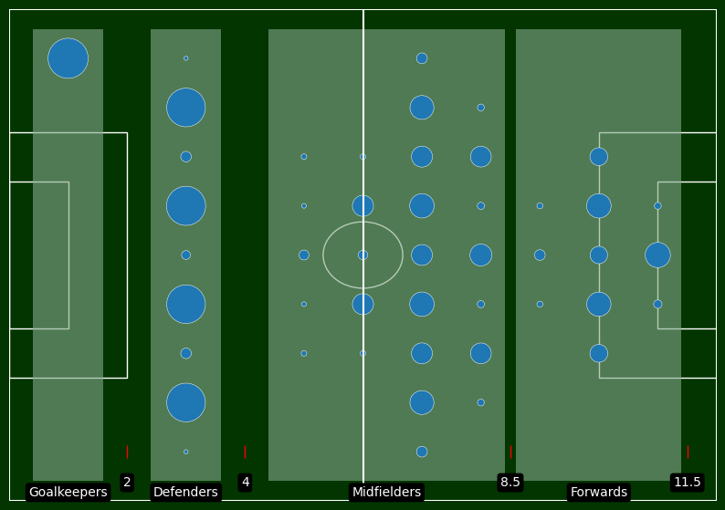

```python
field.plot_all_players(get_player_positions_all())
```

Based on this quick check, we can make a *judgement call* and decide on the following cutout points:

The Y axis is horizontal in this chart, since this is the scale that is used in the original dataset. It's just a namin convention we can ignore (no hassle!)

- Goalies are always on position `Y=1` (interestingly, they are all marked as x=1 and y=1)
- Defenders are between `Y=2` and `Y=4`
- Midfielders are between `Y=4` and `Y=8` (included)
- Forwards are between `Y=9` and `Y=12` (included)

The cutoff points can be used to categorize players accordingly

```python
position_cutpoints = {
    "goalkeeper": 2,
    "defense": 4,
    "midfielder": 8.5,
    "forward": 12,
}
```

```python
def melt_player_y_pos(df):
    return df.melt(
        id_vars=["match_api_id", "date"],
        value_vars=columns_for(["away_player_y", "home_player_y"]),
        value_name="y_position",
        var_name="player_position",
    )


def cast_and_drop_nas(df: pd.DataFrame) -> pd.DataFrame:
    df["date"] = pd.to_datetime(pd.to_datetime(df["date"]).dt.date)
    df = df[~df["y_position"].isna()]
    df["y_position"] = df["y_position"].astype("int")
    df["player_position"] = df["player_position"].str.replace("_y", "_")
    return df


def assign_player_position_description(df, cuts=dict[str, float]) -> pd.DataFrame:
    df["position"] = "unknown"
    for name, cut in sorted(cuts.items(), key=lambda x: x[1], reverse=True):
        df.loc[df["y_position"] <= cut, "position"] = name
    return df


match_positions = (
    match_players.clone()
    .step(melt_player_y_pos)
    .step(cast_and_drop_nas)
    .step(assign_player_position_description, cuts=position_cutpoints)
)
match_positions.peek_df()
```

```
[melt_player_y_pos] took 0.07s. {'shape': (531080, 4), 'shape_diff': '[506940    -42]'}
[cast_and_drop_nas] took 0.83s. {'shape': (531080, 4)}
[assign_player_position_description] took 0.02s. {'shape': (531080, 5), 'shape_diff': '[0 1]'}
```

|  | match_api_id | date | player_position | y_position | position |
| --- | --- | --- | --- | --- | --- |
| 0 | 493016 | 2009-02-28 | away_player_1 | 1 | goalkeeper |
| 1 | 493017 | 2009-02-27 | away_player_1 | 1 | goalkeeper |
| 2 | 493018 | 2009-02-28 | away_player_1 | 1 | goalkeeper |
| 3 | 493019 | 2009-03-01 | away_player_1 | 1 | goalkeeper |
| 4 | 493020 | 2009-03-01 | away_player_1 | 1 | goalkeeper |
| ... | ... | ... | ... | ... | ... |
| 531075 | 1992091 | 2015-09-22 | home_player_11 | 11 | forward |
| 531076 | 1992092 | 2015-09-23 | home_player_11 | 11 | forward |
| 531077 | 1992093 | 2015-09-23 | home_player_11 | 11 | forward |
| 531078 | 1992094 | 2015-09-22 | home_player_11 | 10 | forward |
| 531079 | 1992095 | 2015-09-23 | home_player_11 | 10 | forward |

531080 rows × 5 columns

```
<utils.pipeline_utils.Pipeline at 0x2a9e0029340>
```

```
Loading from cache [./cached/charts/player_positions.png]
```

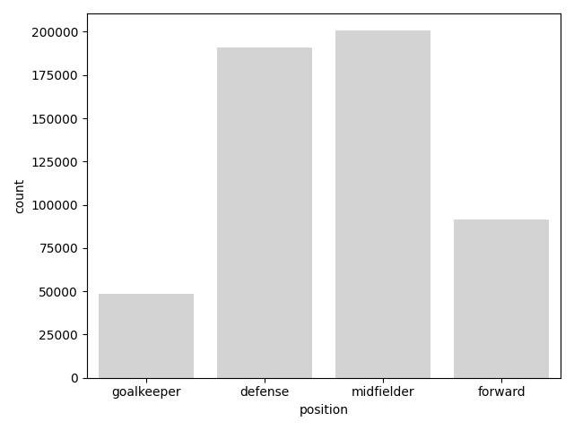

```python
@run
@cached_chart()
def player_positions():
    return sns.countplot(data=match_positions.df(), x="position", color="lightgrey")
```

Let's enrich the match summary with the player positions, so we can group them later

```python
match_summary.step(munge.enrich_with_player_positions, positions=match_positions.df())
match_summary.step(munge.add_team_column)
```

```
[enrich_with_player_positions] took 0.53s. {'shape': (531080, 45), 'shape_diff': '[0 1]'}
[add_team_column] took 0.38s. {'shape': (531080, 46), 'shape_diff': '[0 1]'}
```

```
<utils.pipeline_utils.Pipeline at 0x2a9c603ceb0>
```

```python
match_aggs = (
    match_summary.clone()
    .step(munge.drop_unused_fields)
    .step(munge.convert_work_rates_to_numeric)
    .step(munge.aggregate_attributes_by_team_position, peek=True)
    .step(munge.expand_to_columns, peek=True)
)
```

```
[drop_unused_fields] took 0.01s. {'shape': (531080, 41), 'shape_diff': '[ 0 -5]'}
[convert_work_rates_to_numeric] took 0.08s. {'shape': (531080, 41)}
[aggregate_attributes_by_team_position] took 0.47s. {'shape': (193120, 38), 'shape_diff': '[-337960      -3]'}
```

Peeking after `aggregate_attributes_by_team_position`

| match_api_id | team | position | overall_rating | potential | attacking_work_rate | defensive_work_rate | crossing | finishing | heading_accuracy | short_passing | volleys | dribbling | ... | penalties | marking | standing_tackle | sliding_tackle | gk_diving | gk_handling | gk_kicking | gk_positioning | gk_reflexes | count |
| --- | --- | --- | --- | --- | --- | --- | --- | --- | --- | --- | --- | --- | --- | --- | --- | --- | --- | --- | --- | --- | --- | --- | --- |
| 1002982 | away | defense | 285 | 302 | 26 | 20 | 259 | 84 | 277 | 276 | 117 | 241 | ... | 90 | 281 | 298 | 273 | 40 | 37 | 37 | 35 | 34 | 4 |
|  |  | forward | 147 | 159 | 10 | 10 | 116 | 161 | 150 | 138 | 133 | 148 | ... | 137 | 32 | 38 | 31 | 25 | 12 | 16 | 27 | 22 | 2 |
|  |  | goalkeeper | 71 | 78 | 5 | 5 | 18 | 16 | 12 | 29 | 18 | 19 | ... | 21 | 12 | 12 | 11 | 74 | 71 | 61 | 73 | 76 | 1 |
|  |  | midfielder | 289 | 316 | 23 | 26 | 268 | 226 | 222 | 303 | 206 | 290 | ... | 222 | 273 | 291 | 271 | 40 | 33 | 36 | 44 | 39 | 4 |
|  | home | defense | 295 | 318 | 15 | 23 | 217 | 90 | 312 | 269 | 69 | 225 | ... | 193 | 304 | 307 | 274 | 42 | 36 | 47 | 37 | 50 | 4 |
| ... | ... | ... | ... | ... | ... | ... | ... | ... | ... | ... | ... | ... | ... | ... | ... | ... | ... | ... | ... | ... | ... | ... | ... |
| 954555 | away | midfielder | 287 | 329 | 28 | 25 | 273 | 244 | 260 | 289 | 237 | 292 | ... | 235 | 259 | 274 | 247 | 53 | 52 | 38 | 49 | 49 | 5 |
|  | home | defense | 244 | 290 | 20 | 20 | 220 | 151 | 239 | 239 | 175 | 202 | ... | 216 | 243 | 251 | 226 | 49 | 37 | 38 | 34 | 49 | 4 |
|  |  | forward | 131 | 150 | 10 | 10 | 117 | 137 | 91 | 126 | 115 | 140 | ... | 123 | 27 | 44 | 38 | 16 | 30 | 28 | 17 | 26 | 2 |
|  |  | goalkeeper | 72 | 79 | 5 | 5 | 25 | 25 | 25 | 21 | 25 | 25 | ... | 23 | 25 | 25 | 25 | 75 | 73 | 60 | 69 | 74 | 1 |
|  |  | midfielder | 261 | 305 | 23 | 20 | 255 | 246 | 235 | 281 | 244 | 259 | ... | 251 | 209 | 197 | 156 | 35 | 35 | 31 | 34 | 47 | 4 |

193120 rows × 38 columns

```
[expand_to_columns] took 0.33s. {'shape': (24140, 304), 'shape_diff': '[-168980     266]'}
```

Peeking after `expand_to_columns`

| match_api_id | overall_rating_away_defense | overall_rating_away_forward | overall_rating_away_goalkeeper | overall_rating_away_midfielder | overall_rating_home_defense | overall_rating_home_forward | overall_rating_home_goalkeeper | overall_rating_home_midfielder | potential_away_defense | potential_away_forward | ... | gk_reflexes_home_goalkeeper | gk_reflexes_home_midfielder | count_away_defense | count_away_forward | count_away_goalkeeper | count_away_midfielder | count_home_defense | count_home_forward | count_home_goalkeeper | count_home_midfielder |
| --- | --- | --- | --- | --- | --- | --- | --- | --- | --- | --- | --- | --- | --- | --- | --- | --- | --- | --- | --- | --- | --- |
| 1002982 | 285 | 147 | 71 | 289 | 295 | 143 | 79 | 281 | 302 | 159 | ... | 82 | 43 | 4 | 2 | 1 | 4 | 4 | 2 | 1 | 4 |
| 1005014 | 252 | 51 | 70 | 329 | 259 | 75 | 68 | 342 | 275 | 62 | ... | 68 | 57 | 4 | 1 | 1 | 5 | 4 | 1 | 1 | 5 |
| 1005015 | 268 | 131 | 66 | 204 | 203 | 132 | 66 | 270 | 290 | 134 | ... | 71 | 37 | 4 | 2 | 1 | 4 | 4 | 2 | 1 | 4 |
| 1005016 | 254 | 61 | 66 | 293 | 237 | 60 | 63 | 318 | 268 | 69 | ... | 64 | 48 | 4 | 1 | 1 | 5 | 4 | 1 | 1 | 5 |
| 1005017 | 250 | 126 | 62 | 254 | 248 | 124 | 62 | 196 | 264 | 140 | ... | 64 | 38 | 4 | 2 | 1 | 4 | 4 | 2 | 1 | 4 |
| ... | ... | ... | ... | ... | ... | ... | ... | ... | ... | ... | ... | ... | ... | ... | ... | ... | ... | ... | ... | ... | ... |
| 954551 | 128 | 59 | 66 | 328 | 268 | 150 | 75 | 274 | 140 | 63 | ... | 83 | 49 | 4 | 1 | 1 | 5 | 4 | 2 | 1 | 4 |
| 954552 | 196 | 66 | 57 | 281 | 179 | 120 | 0 | 176 | 217 | 70 | ... | 0 | 27 | 4 | 1 | 1 | 5 | 4 | 3 | 1 | 3 |
| 954553 | 236 | 125 | 66 | 241 | 253 | 119 | 58 | 249 | 274 | 140 | ... | 64 | 50 | 4 | 2 | 1 | 4 | 4 | 2 | 1 | 4 |
| 954554 | 234 | 59 | 62 | 318 | 263 | 63 | 71 | 334 | 251 | 70 | ... | 77 | 58 | 4 | 1 | 1 | 5 | 4 | 1 | 1 | 5 |
| 954555 | 218 | 65 | 62 | 287 | 244 | 131 | 72 | 261 | 252 | 72 | ... | 74 | 47 | 4 | 1 | 1 | 5 | 4 | 2 | 1 | 4 |

24140 rows × 304 columns

Let's do a quick check and verify that this dataframe looks the way it should:

- there should be always 1 goalkeeper.
- there should be some variability in all other positions, but not by a lot.
- for each of positions for each of the teams (home/away):
  - the sum of Max values should be above 11, but not by a lot.
  - the sum of Min values should be below 11, but not by a lot.
- home team and Away team distributions should look almost identical. (since not many teams change their formation when playing home vs abroad)

```
Loading from cache [./cached/charts/positions_spread.png]
```

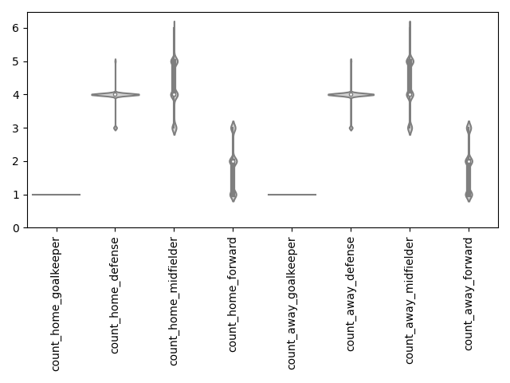

```python
@run
@cached_chart()
def positions_spread():
    g = sns.violinplot(
        data=match_aggs.df()[
            [
                "count_home_goalkeeper",
                "count_home_defense",
                "count_home_midfielder",
                "count_home_forward",
                "count_away_goalkeeper",
                "count_away_defense",
                "count_away_midfielder",
                "count_away_forward",
            ]
        ],
        color="lightgrey",
    )
    plt.ylim(0)
    charts.rotate_x_labels()
    return g
```

Everything looks like we anticipated! ✅

Let's enrich our dataset with Score information. We are going to need:

```
[select_match_result_cols] took 0.00s. {'shape': (25979, 3), 'shape_diff': '[  0 -79]'}
[add_col_home_team_goal_advantage] took 0.00s. {'shape': (25979, 4), 'shape_diff': '[0 1]'}
[enrich_with_win_result] took 0.00s. {'shape': (25979, 5), 'shape_diff': '[0 1]'}
```

Peeking after `enrich_with_win_result`

|  | match_api_id | home_team_goal | away_team_goal | home_team_goal_advantage | home_team_win |
| --- | --- | --- | --- | --- | --- |
| 0 | 492473 | 1 | 1 | 0 | 0 |
| 1 | 492474 | 0 | 0 | 0 | 0 |
| 2 | 492475 | 0 | 3 | -3 | 0 |
| 3 | 492476 | 5 | 0 | 5 | 1 |
| 4 | 492477 | 1 | 3 | -2 | 0 |
| ... | ... | ... | ... | ... | ... |
| 25974 | 1992091 | 1 | 0 | 1 | 1 |
| 25975 | 1992092 | 1 | 2 | -1 | 0 |
| 25976 | 1992093 | 2 | 0 | 2 | 1 |
| 25977 | 1992094 | 0 | 0 | 0 | 0 |
| 25978 | 1992095 | 4 | 3 | 1 | 1 |

25979 rows × 5 columns

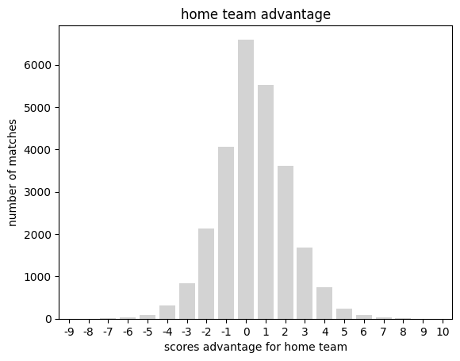

```python
goals_p = (
    match_p.clone()
    .step(munge.select_match_result_cols)
    .step(munge.add_col_home_team_goal_advantage)
    .peek(munge.plot_advantage)
    .step(munge.enrich_with_win_result, peek=True)
)
```

The chart also looks like we expected:

- looks like a gausian-ish bell curve
- centered around ~0 (tie)
- it seems to show a home team advantage (`+1` is taller than `-1`, `+2` is taller than `-2`, etc...)
  - which explains why the mean is positive
  - but we want to verify if this is strong enough to be statistically significant
  - let's calculate it:

### Does home team advantage exist?

We can try to determine if there is statistically significant evidence of "home team advantage":

We could use a couple of different fields to determine this:

```python
ci = 0.95
```

```python
goal_adv = goals_p.df()["home_team_goal_advantage"]
stats.norm(goal_adv.mean(), goal_adv.std()).interval(confidence=ci)
```

```
(-3.1097901146067786, 3.877102174347338)
```

```python
goal_adv = goals_p.df()["home_team_win"]
stats.norm(goal_adv.mean(), goal_adv.std()).interval(confidence=ci)
```

```
(-0.517938026060065, 1.4353713375809087)
```

On the one hand, we can see that, if discount the ties, there are more home wins than away wins.

On the other hand, if we use a confidence interval of 95%, **we cannot reject the null hypothesis that there is no such thing as a home team advantage**, whether we use "goal difference", or "home team win vs no win"

### Enriching our match data with goal information

Let's continue enriching our match data with goal results, so we can use the result to train our model

```python
match_aggs.step(munge.enrich_with_goals, goals_df=goals_p.df())
match_aggs.step(munge.drop_goals_cols)
__
```

```
[enrich_with_goals] took 0.13s. {'shape': (24140, 309), 'shape_diff': '[0 5]'}
[drop_goals_cols] took 0.00s. {'shape': (24140, 307), 'shape_diff': '[ 0 -2]'}
```

We're ready to start creating models. We will clone our pipeline and create 2 forked pipelines:

- one for the linear regression model
- the other one for the logistic regression model

Then, for each of them, we are going to:

- split it into training/test data (first)
- normalize/scale it

The order matters because we want our 2 slices to be independent (test data should have no idea of the range of data in the training dataset)

### Forking into 2 separate pipelines

```python
linear_match_aggs = match_aggs.clone()
linear_match_aggs.step(munge.drop_home_team_win)

logistic_match_aggs = match_aggs.clone()
logistic_match_aggs.step(munge.drop_home_advantage_cols)
```

```
[drop_home_team_win] took 0.00s. {'shape': (24140, 306), 'shape_diff': '[ 0 -1]'}
[drop_home_advantage_cols] took 0.01s. {'shape': (24140, 306), 'shape_diff': '[ 0 -1]'}
```

```
<utils.pipeline_utils.Pipeline at 0x2a9c60162e0>
```

Now that we have 2 pipelines forked from the same original data, we can also do the Train/Test split in both of them.

```python
predict_advantage_model = linear_match_aggs.train_test_split(
    target_col="home_team_goal_advantage", random_state=1
).scale_using_minmax()
```

```
<TrainTestData instance>
Training = X:(16898, 305), y:(16898, 1)
Test = X:(7242, 305), y:(7242,)
```

```python
predict_win_model = logistic_match_aggs.train_test_split(
    target_col="home_team_win", random_state=1
).scale_using_standard_scaler()
```

```
<TrainTestData instance>
Training = X:(16898, 305), y:(16898,)
Test = X:(7242, 305), y:(7242,)
```

The split is guaranteed to be the same for both datasets because we used the same random seed (same Index on both dataframes).

However, the scaling will be different, because we are using different scaling strategies:

- for **linear** regression, to predict goal difference in `home_team_goal_advantage`, we used **MinMax**
- for **logistic** regression, to predict win/nowin in `home_team_win`, we used **StandardScaler**

## Predicting wins using Linear Regression

The next step requires us to assess how our data structure works, and if it makes any sense from the domain's point of view.

We can use SelectKBest to see if the data we have put together makes sense.

We expect several things:

1. Some values will contribute nothing (eg. number of goalkeepers), because they never change (always = 1)
2. Some values will contribute very little (e.g. number of players in X position), because having 4 players vs 3 players is not as important as who those players are (and their skills)
3. Some values will contribute a lot (in this regard, I will not make predictions because football is not my strength), but I imagine they would be attributes that my uncle might complain about at the bar... maybe speed, assistance to other players, etc..
4. Goalkeeper skills:
   1. The goalkeeper attributes of players in the goalkeeper position contribute a lot
   2. The goalkeeper attributes of players NOT in the goalkeeper position contribute almost nothing (eg. no one cares if a midfielder is not great at stopping shots because they never use these skills in matches)
5. The spread of important features will likely be spread across a variety of attributes (home/away, diverse positions, ...) and will have no discernible pattern (to me, a data scientist with little football watching skills)

let's include them all initially, so we can see if our model correctly identifies contributions that make sense

```python
def calculate_kbest(X_train, X_test, y_train, y_test, k):
    selector = SelectKBest(score_func=f_regression, k=k)
    selector.fit(X_train, y_train)

    selected_features = selector.get_support(indices=True)
    feature_scores = selector.scores_[selected_features]
    features_series = pd.Series(feature_scores, index=X_train.columns[selected_features])
    features_series_sorted = features_series.sort_values(ascending=False)
    return (
        selector,
        selected_features,
        feature_scores,
        features_series,
        features_series_sorted,
    )


X_train, X_test, y_train, y_test = predict_advantage_model.data()

k = X_train.shape[1]  # all

(
    selector,
    selected_features,
    feature_scores,
    features_series,
    features_series_sorted,
) = calculate_kbest(X_train, X_test, y_train, y_test, k=k)
```

```python
features_series_sorted = munge.categorize_features(features_series_sorted)
features_series_sorted
```

|  | attribute | weight | team | position |
| --- | --- | --- | --- | --- |
| 0 | dribbling_home_defense | 413.007282 | 🟥 home | 🟩 defense |
| 1 | vision_home_defense | 405.244088 | 🟥 home | 🟩 defense |
| 2 | volleys_home_defense | 398.847269 | 🟥 home | 🟩 defense |
| 3 | short_passing_home_defense | 395.444912 | 🟥 home | 🟩 defense |
| 4 | long_passing_home_defense | 383.924246 | 🟥 home | 🟩 defense |
| ... | ... | ... | ... | ... |
| 300 | sliding_tackle_away_goalkeeper | 0.031451 | 🟦 away | 🟥 goalkeeper |
| 301 | free_kick_accuracy_home_goalkeeper | 0.015362 | 🟥 home | 🟥 goalkeeper |
| 302 | gk_positioning_away_midfielder | 0.001357 | 🟦 away | 🟨 midfielder |
| 303 | count_away_goalkeeper | 0.000000 | 🟦 away | 🟥 goalkeeper |
| 304 | count_home_goalkeeper | 0.000000 | 🟥 home | 🟥 goalkeeper |

305 rows × 4 columns

Let's inspect the top/bottom of this dataframe with a bit more care

```python
features_series_sorted.head(45)
```

|  | attribute | weight | team | position |
| --- | --- | --- | --- | --- |
| 0 | dribbling_home_defense | 413.007282 | 🟥 home | 🟩 defense |
| 1 | vision_home_defense | 405.244088 | 🟥 home | 🟩 defense |
| 2 | volleys_home_defense | 398.847269 | 🟥 home | 🟩 defense |
| 3 | short_passing_home_defense | 395.444912 | 🟥 home | 🟩 defense |
| 4 | long_passing_home_defense | 383.924246 | 🟥 home | 🟩 defense |
| 5 | reactions_home_defense | 380.892454 | 🟥 home | 🟩 defense |
| 6 | ball_control_home_defense | 369.529627 | 🟥 home | 🟩 defense |
| 7 | long_shots_home_defense | 362.503120 | 🟥 home | 🟩 defense |
| 8 | sliding_tackle_home_defense | 354.159763 | 🟥 home | 🟩 defense |
| 9 | curve_home_defense | 350.167526 | 🟥 home | 🟩 defense |
| 10 | shot_power_home_defense | 348.910555 | 🟥 home | 🟩 defense |
| 11 | interceptions_home_defense | 344.518388 | 🟥 home | 🟩 defense |
| 12 | overall_rating_home_defense | 338.215229 | 🟥 home | 🟩 defense |
| 13 | potential_home_defense | 320.141855 | 🟥 home | 🟩 defense |
| 14 | marking_home_defense | 312.393754 | 🟥 home | 🟩 defense |
| 15 | finishing_home_defense | 306.154902 | 🟥 home | 🟩 defense |
| 16 | standing_tackle_home_defense | 302.520834 | 🟥 home | 🟩 defense |
| 17 | penalties_home_defense | 295.747512 | 🟥 home | 🟩 defense |
| 18 | crossing_home_defense | 289.202579 | 🟥 home | 🟩 defense |
| 19 | dribbling_away_defense | 287.310845 | 🟦 away | 🟩 defense |
| 20 | heading_accuracy_home_defense | 275.659352 | 🟥 home | 🟩 defense |
| 21 | positioning_home_defense | 271.096293 | 🟥 home | 🟩 defense |
| 22 | free_kick_accuracy_home_defense | 270.570566 | 🟥 home | 🟩 defense |
| 23 | short_passing_away_defense | 267.974358 | 🟦 away | 🟩 defense |
| 24 | ball_control_away_defense | 254.427111 | 🟦 away | 🟩 defense |
| 25 | long_passing_away_defense | 252.695036 | 🟦 away | 🟩 defense |
| 26 | shot_power_away_defense | 250.018962 | 🟦 away | 🟩 defense |
| 27 | vision_away_defense | 243.231954 | 🟦 away | 🟩 defense |
| 28 | agility_home_defense | 241.380063 | 🟥 home | 🟩 defense |
| 29 | long_shots_away_defense | 240.830260 | 🟦 away | 🟩 defense |
| 30 | volleys_away_defense | 240.011028 | 🟦 away | 🟩 defense |
| 31 | sprint_speed_home_defense | 233.578517 | 🟥 home | 🟩 defense |
| 32 | acceleration_home_defense | 232.897343 | 🟥 home | 🟩 defense |
| 33 | aggression_home_defense | 227.472545 | 🟥 home | 🟩 defense |
| 34 | sliding_tackle_away_defense | 226.796863 | 🟦 away | 🟩 defense |
| 35 | curve_away_defense | 225.740353 | 🟦 away | 🟩 defense |
| 36 | potential_away_defense | 224.683492 | 🟦 away | 🟩 defense |
| 37 | stamina_home_defense | 224.487336 | 🟥 home | 🟩 defense |
| 38 | penalties_away_defense | 223.899480 | 🟦 away | 🟩 defense |
| 39 | overall_rating_away_defense | 222.758336 | 🟦 away | 🟩 defense |
| 40 | volleys_home_forward | 222.751175 | 🟥 home | 🟪 forward |
| 41 | reactions_away_defense | 222.366883 | 🟦 away | 🟩 defense |
| 42 | interceptions_away_defense | 217.909452 | 🟦 away | 🟩 defense |
| 43 | attacking_work_rate_home_defense | 217.808635 | 🟥 home | 🟩 defense |
| 44 | overall_rating_away_goalkeeper | 217.372038 | 🟦 away | 🟥 goalkeeper |

```python
features_series_sorted.tail(20)
```

|  | attribute | weight | team | position |
| --- | --- | --- | --- | --- |
| 285 | dribbling_home_goalkeeper | 2.554117 | 🟥 home | 🟥 goalkeeper |
| 286 | finishing_home_goalkeeper | 1.939611 | 🟥 home | 🟥 goalkeeper |
| 287 | gk_reflexes_away_midfielder | 1.808472 | 🟦 away | 🟨 midfielder |
| 288 | match_api_id | 1.565224 | 🟥 home | 🟥 goalkeeper |
| 289 | volleys_away_goalkeeper | 1.505525 | 🟦 away | 🟥 goalkeeper |
| 290 | gk_handling_home_midfielder | 1.051888 | 🟥 home | 🟨 midfielder |
| 291 | marking_home_goalkeeper | 0.962991 | 🟥 home | 🟥 goalkeeper |
| 292 | sliding_tackle_home_goalkeeper | 0.794001 | 🟥 home | 🟥 goalkeeper |
| 293 | long_shots_home_goalkeeper | 0.646338 | 🟥 home | 🟥 goalkeeper |
| 294 | gk_handling_away_midfielder | 0.449957 | 🟦 away | 🟨 midfielder |
| 295 | gk_positioning_home_midfielder | 0.379786 | 🟥 home | 🟨 midfielder |
| 296 | curve_away_goalkeeper | 0.271820 | 🟦 away | 🟥 goalkeeper |
| 297 | free_kick_accuracy_away_goalkeeper | 0.115287 | 🟦 away | 🟥 goalkeeper |
| 298 | curve_home_goalkeeper | 0.068774 | 🟥 home | 🟥 goalkeeper |
| 299 | volleys_home_goalkeeper | 0.042998 | 🟥 home | 🟥 goalkeeper |
| 300 | sliding_tackle_away_goalkeeper | 0.031451 | 🟦 away | 🟥 goalkeeper |
| 301 | free_kick_accuracy_home_goalkeeper | 0.015362 | 🟥 home | 🟥 goalkeeper |
| 302 | gk_positioning_away_midfielder | 0.001357 | 🟦 away | 🟨 midfielder |
| 303 | count_away_goalkeeper | 0.000000 | 🟦 away | 🟥 goalkeeper |
| 304 | count_home_goalkeeper | 0.000000 | 🟥 home | 🟥 goalkeeper |

Once more, this model confirms all of the expectations we had:

- ✅ 0 contribution for `count_home_goalkeeper` and `count_away_goalkeeper`
- ✅ `gk_handling_away_midfielder`, `gk_positioning_home_midfielder`, etc... = show tiny contributions (most likely negligible noise)
- ✅ `gk_positioning_away_goalkeeper` (goalkeeper skills for goalkeeper players) = contribute a lot
- ⁉ `🟩 defense` attributes have the strongest contributions and dominate the first 40 spots
  - I am not sure if this is correct. I am not a football expert, but it seems fishy.
  - Based on my rare experience, I thought the `🟪 forward` players would have a more significant contribution.
  - Those seem to be the stars on fashion magazines (?) Are fashion magazines and celebrity gossip advice not the right source of business insights for my football analysis? Oh no!
  - Going back to the topic discussed at the beginning of this analysis, it is very possible that this could be caused by observer's bias.
- ✅ The `🟥 home` attributes also score higher and contribute better to the final prediction, taking up the first 19 spots.
  - Unexpected (but not by a lot) because home advantage does not necessarily mean that the home team is better, it could also have been explained by the away team performing worse.

### Let's predict match results

So, with these results, we're fairly happy that we've been able to do a good job to munge/shape our original data into something that makes sense. Let's call it "good enough" given our limited business insights.

The next step is to use this data to create a brand new model (from scratch) that can predict match results.

As a reminder, let's recall [the warning in the kaggle dataset](https://www.kaggle.com/datasets/prajitdatta/ultimate-25k-matches-football-database-european):

> The Holy Grail… is obviously to predict the outcome of the game.

> The bookies use 3 classes (Home Win, Draw, Away Win). They get it right about 53% of the time. This is also what I've achieved so far using my own SVM. Though it may sound high for such a random sport game, you've got to know that the home team wins about 46% of the time. So the base case (constantly predicting Home Win) has indeed 46% precision.

> Prajit Datta, Dataset author, 2017
- So... basically:
  - Flip a proverbial coin: 46% success
  - ...
  - Top performing business operating in this space 53%

That's a narrow 7 percentage points of range between the most naive strategy (flip a coin) and strongest ones (the strategies employed by the betting industry with multi-billion $ in profits).

Can you try to guess how our new model will perform?

🍿 Let's get some popcorn and hope for the best

```python
linear_match_aggs.df()
```

|  | match_api_id | overall_rating_away_defense | overall_rating_away_forward | overall_rating_away_goalkeeper | overall_rating_away_midfielder | overall_rating_home_defense | overall_rating_home_forward | overall_rating_home_goalkeeper | overall_rating_home_midfielder | potential_away_defense | ... | gk_reflexes_home_midfielder | count_away_defense | count_away_forward | count_away_goalkeeper | count_away_midfielder | count_home_defense | count_home_forward | count_home_goalkeeper | count_home_midfielder | home_team_goal_advantage |
| --- | --- | --- | --- | --- | --- | --- | --- | --- | --- | --- | --- | --- | --- | --- | --- | --- | --- | --- | --- | --- | --- |
| 0 | 1002982 | 285 | 147 | 71 | 289 | 295 | 143 | 79 | 281 | 302 | ... | 43 | 4 | 2 | 1 | 4 | 4 | 2 | 1 | 4 | 0 |
| 1 | 1005014 | 252 | 51 | 70 | 329 | 259 | 75 | 68 | 342 | 275 | ... | 57 | 4 | 1 | 1 | 5 | 4 | 1 | 1 | 5 | 2 |
| 2 | 1005015 | 268 | 131 | 66 | 204 | 203 | 132 | 66 | 270 | 290 | ... | 37 | 4 | 2 | 1 | 4 | 4 | 2 | 1 | 4 | 0 |
| 3 | 1005016 | 254 | 61 | 66 | 293 | 237 | 60 | 63 | 318 | 268 | ... | 48 | 4 | 1 | 1 | 5 | 4 | 1 | 1 | 5 | 0 |
| 4 | 1005017 | 250 | 126 | 62 | 254 | 248 | 124 | 62 | 196 | 264 | ... | 38 | 4 | 2 | 1 | 4 | 4 | 2 | 1 | 4 | -3 |
| ... | ... | ... | ... | ... | ... | ... | ... | ... | ... | ... | ... | ... | ... | ... | ... | ... | ... | ... | ... | ... | ... |
| 24135 | 954551 | 128 | 59 | 66 | 328 | 268 | 150 | 75 | 274 | 140 | ... | 49 | 4 | 1 | 1 | 5 | 4 | 2 | 1 | 4 | 3 |
| 24136 | 954552 | 196 | 66 | 57 | 281 | 179 | 120 | 0 | 176 | 217 | ... | 27 | 4 | 1 | 1 | 5 | 4 | 3 | 1 | 3 | 2 |
| 24137 | 954553 | 236 | 125 | 66 | 241 | 253 | 119 | 58 | 249 | 274 | ... | 50 | 4 | 2 | 1 | 4 | 4 | 2 | 1 | 4 | 0 |
| 24138 | 954554 | 234 | 59 | 62 | 318 | 263 | 63 | 71 | 334 | 251 | ... | 58 | 4 | 1 | 1 | 5 | 4 | 1 | 1 | 5 | 2 |
| 24139 | 954555 | 218 | 65 | 62 | 287 | 244 | 131 | 72 | 261 | 252 | ... | 47 | 4 | 1 | 1 | 5 | 4 | 2 | 1 | 4 | 1 |

24140 rows × 306 columns

```python
k = 30
X_train, X_test, y_train, y_test = predict_advantage_model.data()

selector = SelectKBest(score_func=f_regression, k=k)
selector.fit(X_train, y_train)
feats = selector.get_feature_names_out()
support = selector.get_support()
X_train_selected = selector.transform(X_train)
X_test_selected = selector.transform(X_test)

model = LinearRegression()
model.fit(X_train_selected, y_train)
predicted = model.predict(X_test_selected)
predicted_unscaled = predict_advantage_model.unscale_y(predicted).squeeze()
diffs = y_test.values - predicted_unscaled
score = model.score(X_train_selected, y_train)
```

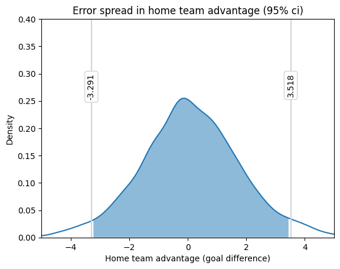

```python
ci = 0.95
charts.kde_with_ci(diffs.to_numpy(), ci=ci)
plt.title(f"Error spread in home team advantage ({ci*100:.0f}% ci)")
plt.xlabel("Home team advantage (goal difference)")
plt.xlim(-5, 5)
plt.ylim(0, 0.4)
__
```

This model is an atrocity... it fails more than ChatGPT trying to create funny analogies about how bad my model is.

+- 3.4 goals for the 95% confidence interval...? wow!

This is worse than a coinflip

```python
md(f"something not completely unexpected, given that the score was {score}")
```

something not completely unexpected, given that the score was 0.07296824599455765

### Using this flawed model to predict home team wins

Let's try 2 different approaches to improve this model:

- rounding the prediction (naive approach)
- using a confidence threshold so we only bet on high-confidence predictions
  - Q: how much confidence do we need to have a strong guarantee to win?

### Rounding the predictions

Can we try rounding the predicted result, and see how the errors look like?

I don't think it will improve thing, but as a naive approach, I'd like to see how the output changes...

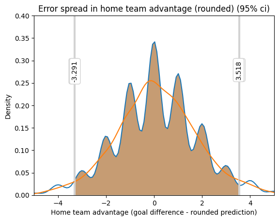

```python
rounded_predictions = np.round(predicted_unscaled)
rounded_diffs = y_test - rounded_predictions

ci = 0.95
charts.kde_with_ci(rounded_diffs.values.to_numpy(), ci=ci, ax=plt.gca())
charts.kde_with_ci(diffs.to_numpy(), ci=ci, ax=plt.gca())
plt.title(f"Error spread in home team advantage (rounded) ({ci*100:.0f}% ci)")
plt.xlabel("Home team advantage (goal difference - rounded prediction)")
plt.xlim(-5, 5)
plt.ylim(0, 0.4)
__
```

As we can see, the overall errors have almost the same spread, so this avenue makes little sense to pursue.

The apparent "better performance" is only a redistribution of errors

We need to try other options!

### Increasing the threshold required before trusting the model

Suppose we still want to be able to predict wins, but only when we are VERY confident.

How would our accuracy change if we were to trust this model *only* for cases where we predict a home team win of > 1.8 points? (we want our model to have SOME confidence that they are going to win)

```python
predictions = pd.DataFrame(
    {
        "actual": y_test,
        "predicted": predicted_unscaled,
    }
)

threshold = 1.80
predictions["strong_predicted_win"] = False
predictions.loc[predictions["predicted"] >= threshold, "strong_predicted_win"] = True
print(predictions[predictions["strong_predicted_win"]].shape)
predictions[predictions["strong_predicted_win"]].head()
```

```
(21, 3)
```

|  | actual | predicted | strong_predicted_win |
| --- | --- | --- | --- |
| 16857 | 2 | 1.856998 | True |
| 19341 | 1 | 1.866239 | True |
| 16796 | 3 | 2.338748 | True |
| 15877 | 2 | 1.889684 | True |
| 19400 | 3 | 2.092210 | True |

```
Loading from cache [./cached/charts/prediction_linear.png]
```

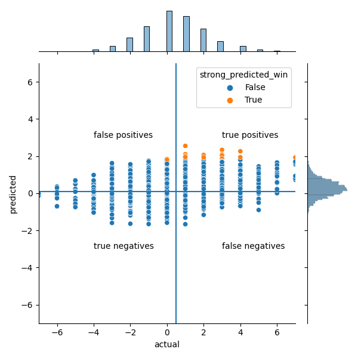

```python
@run
@cached_chart()
def prediction_linear():
    g = sns.JointGrid(
        data=predictions,
        x="actual",
        y="predicted",
        xlim=(-7, 7),
        ylim=(-7, 7),
        hue="strong_predicted_win",
    )
    g.plot(sns.scatterplot, sns.histplot)

    g.ax_joint.axvline(x=0.5)
    g.ax_joint.axhline(y=0.1)  # let's consider 0.1 to be "tie"
    g.ax_joint.text(3, 3, "true positives")
    g.ax_joint.text(-4, -3, "true negatives")
    g.ax_joint.text(3, -3, "false negatives")
    g.ax_joint.text(-4, 3, "false positives")
    return g.fig
```

It didn't really work!

- On the one hand, it has pretty **good precision**
- On the other hand, it has **terrible recall**; there are **very few** results
- In addition, the threshold was chosen without any statistical methodologies... Just what seemed "good enough". The precision drops really fast if you decide to use a different threshold for confidence.
- The distribution shows no real change variation as actual goals increase. the ideal shape would be a progression following a (1,1) vector

This strategy is really bad. Let's try to find out why.

First, let's review all of the steps we performed to get here.

```python
linear_match_aggs.peek_steps()
```

```
['0.25s - auto_ndtypes',
 '0.00s - drop_ps_bets',
 '0.40s - convert_player_ids_to_str',
 '0.01s - drop_columns_with_prefix',
 '0.01s - drop_columns_with_prefix',
 '0.01s - drop_xml_fields',
 '0.22s - visualize_na_per_year',
 '0.01s - drop_betting_companies',
 '0.01s - select_player_columns',
 '0.01s - cast_date_col',
 '0.10s - drop_NAs',
 '0.07s - melt_match_players',
 '1.09s - enrich_with_player_info',
 '0.07s - melt_player_y_pos',
 '0.83s - cast_and_drop_nas',
 '0.02s - assign_player_position_description',
 '0.53s - enrich_with_player_positions',
 '0.38s - add_team_column',
 '0.01s - drop_unused_fields',
 '0.08s - convert_work_rates_to_numeric',
 '0.47s - aggregate_attributes_by_team_position',
 '0.33s - expand_to_columns',
 '0.00s - select_match_result_cols',
 '0.00s - add_col_home_team_goal_advantage',
 '0.00s - enrich_with_win_result',
 '0.13s - enrich_with_goals',
 '0.00s - drop_goals_cols',
 '0.00s - drop_home_team_win',
 '0.01s - drop_home_advantage_cols']
```

```
<utils.pipeline_utils.Pipeline at 0x2a9d40f5c10>
```

Nothing seems out of place... I don't think we've forgotten anything

(although, it's pretty nice to get the entire history of pipeline steps in 1-line)

Let's try to plot the actual results, and the predictions:

```
all df =	(0.3828086164043082, 1.7897187352090271)
predicted_df =	(0.2789961913778374, 0.4743452391061926)
```

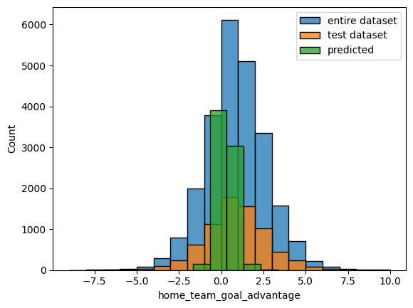

```python
@run
def _():
    ax = plt.gca()
    all_df = linear_match_aggs.df()["home_team_goal_advantage"]
    predicted_df = predictions["predicted"]
    sns.histplot(all_df, ax=ax, binwidth=1, label="entire dataset")
    sns.histplot(predictions["actual"], ax=ax, binwidth=1, label="test dataset")
    sns.histplot(predicted_df, ax=ax, binwidth=1, label="predicted")
    plt.legend()

    print(f"all df =\t{all_df.mean(), all_df.std()}")
    print(f"predicted_df =\t{predicted_df.mean(), predicted_df.std()}")
    return ax
```

A couple of observations

1. The distribution between "all" and "expected" (test dataset) is very similar... so it's not an issue with the way the train/test split was done.
2. The distribution of predictions is very narrow, but seems to be centered correctly.
3. The numbers confirm this:
   1. avg: is almost spot on ✅
   2. std: is too narrow.. ❌

When checking with ChatGPT, what could be the cause for this weird behaviour, we get some interesting insights:

> **Edu**: I am trying to use this code to predict match results [...] the issue is that the spread of the predicted results is really poor...

> home_team_goal_advantage follows a normal-ish distribution with mean = 0.3828086164043082 and sd = 1.7897187352090271...

> but the predicted values have mean = 0.3749169202737588 (good) but SD = 0.47017732799692885 (bad, too small)... what could be causing this? can you provide guidance on how I could fix my code?

> ...

> **BingGPT**: It seems like you’re using a linear regression model to predict the match results. **One possible reason for the small spread of predicted values could be that the relationship between the features and the target variable is not linear.** Have you tried using a different model, such as a decision tree or a random forest, to see if it improves the spread of predicted values?

This is not ideal, because part of the **requirements** for this project was to use linear machine learning models. (🤔 Maybe this is the lesson we're here to learn!)

Let's try with a different type of linear model: Logistic Regression

## Predicting wins using Logistic Regression

Remember that for this predictions we are using a new set of data:

- we are using `predict_win_model` instead of `predict_advantage_model`
- they were both forked from a common pipeline after initial cleaning
- they were both scaled (each with its own distinct scaling strategy)
- `predict_win_model` is a dataframe created to try to predict the home team `win/no win` using logistic regression

For this model, we want to select an optimal number of features: too little and our model has terrible performance, too many features and we're deep into overfitting territory.

Let's try to visualize how LogisticRegression performs, depending on the number of features we select:

```python
def prediction_score_for_features(k: int):
    """
    k: number of top features to select using select k best
    """
    X_train, X_test, y_train, y_test = predict_win_model.data()

    (
        selector,
        selected_features,
        feature_scores,
        features_series,
        features_series_sorted,
    ) = calculate_kbest(X_train, X_test, y_train, y_test, k=k)

    X_train_kbest = X_train.iloc[:, selected_features]
    X_test_kbest = X_test.iloc[:, selected_features]

    random_state = 1
    target_col = "home_team_win"
    model = LogisticRegression(random_state=random_state, max_iter=500)
    model = model.fit(X_train_kbest, y_train)
    predicted = model.predict(X_test_kbest)
    diffs = predicted - y_test
    score = model.score(X_test_kbest, y_test)
    recall = recall_score(y_test, predicted)
    accuracy = accuracy_score(y_test, predicted)
    precision = precision_score(y_test, predicted)
    return y_test, predicted, diffs, score, recall, accuracy, precision
```

```python
scores = {}
for k in range(1, 250, 10):
    (_, _, _, score, recall, accuracy, precision) = prediction_score_for_features(k=k)
    scores[k] = (score, recall, accuracy, precision)
    print(k, score, recall, accuracy, precision)
```

```
1 0.5689036177851422 0.3176680547293278 0.5689036177851422 0.5632911392405063
11 0.5730461198563933 0.34622248661511007 0.5730461198563933 0.565597667638484
21 0.5755316210991439 0.37507436049970255 0.5755316210991439 0.5644583706356312
31 0.6064623032311516 0.4330755502676978 0.6064623032311516 0.6066666666666667
41 0.6190278928472798 0.46876859012492567 0.6190278928472798 0.6182816790898391
51 0.61985639326153 0.466686496133254 0.61985639326153 0.6204033214709371
61 0.6241369787351561 0.47471743010113027 0.6241369787351561 0.6253918495297806
71 0.6260701463684065 0.483343248066627 0.6260701463684065 0.6259630200308166
81 0.6228942281137807 0.48483045806067815 0.6228942281137807 0.6200076074553063
91 0.6311792322562828 0.4943486020226056 0.6311792322562828 0.6312191416635017
101 0.6303507318420326 0.49375371802498513 0.6303507318420326 0.6299810246679317
111 0.6246893123446562 0.49018441403926233 0.6246893123446562 0.6214177978883861
121 0.6271748135874068 0.49881023200475905 0.6271748135874068 0.6229569093610698
131 0.6252416459541563 0.4982153480071386 0.6252416459541563 0.6199111769059955
141 0.6249654791494063 0.49851279000594884 0.6249654791494063 0.6193643754619365
151 0.6291079812206573 0.5035693039857227 0.6291079812206573 0.6247232472324723
161 0.6307649820491577 0.5127900059488399 0.6307649820491577 0.6246376811594203
171 0.632145816072908 0.5172516359309934 0.632145816072908 0.6255395683453238
181 0.6293841480254073 0.5130874479476502 0.6293841480254073 0.6222943722943723
191 0.6253797293565313 0.5113027959547888 0.6253797293565313 0.6163499462172822
201 0.6302126484396575 0.5160618679357525 0.6302126484396575 0.62275664034458
211 0.6293841480254073 0.517846519928614 0.6293841480254073 0.6208987161198288
221 0.6351836509251588 0.5232004759071981 0.6351836509251588 0.6286633309506791
231 0.6329743164871583 0.5223081499107673 0.6329743164871583 0.6253561253561254
241 0.6344932339132836 0.5237953599048185 0.6344932339132836 0.6273601710010688
```

```
Loading from cache [./cached/charts/logisitic_performance.png]
```

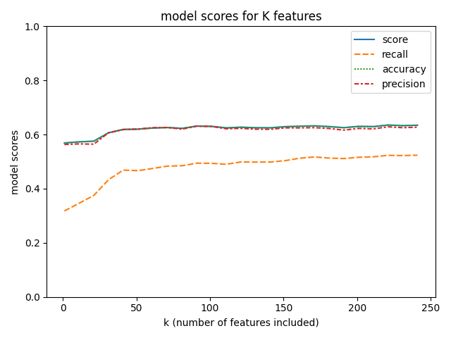

```python
@run
@cached_chart()
def logisitic_performance():
    g = sns.lineplot(
        data=pd.DataFrame(
            scores.values(),
            index=scores.keys(),
            columns=["score", "recall", "accuracy", "precision"],
        )
    )
    plt.xlabel("k (number of features included)")
    plt.ylabel("model scores")
    plt.title("model scores for K features")
    plt.ylim(0, 1)
    return g
```

Something seems weird:

- we get close to 60% score using only 1 feature
- the score is not really improving as more and more features are added

```python
k = 15
(
    y_test,
    predicted,
    diffs,
    score,
    recall,
    accuracy,
    precision,
) = prediction_score_for_features(k=k)
```

```python
predictions = pd.DataFrame(
    {
        "actual": y_test,
        "predicted": predicted,
    }
)
predictions.head()
```

|  | actual | predicted |
| --- | --- | --- |
| 18857 | 1 | 1 |
| 23825 | 1 | 1 |
| 10514 | 0 | 0 |
| 12456 | 0 | 0 |
| 1246 | 1 | 0 |

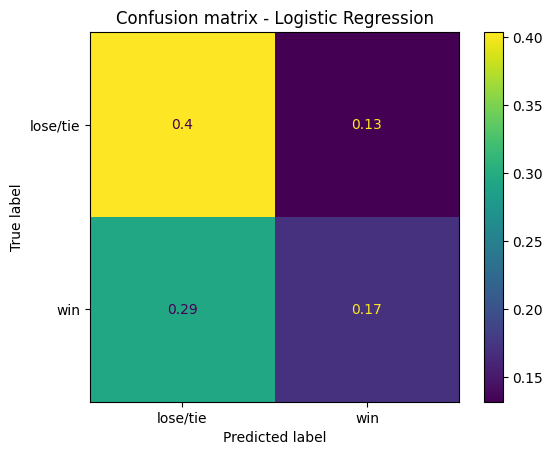

```python
ConfusionMatrixDisplay.from_predictions(
    predictions["actual"],
    predictions["predicted"],
    labels=[0, 1],
    display_labels=["lose/tie", "win"],
    normalize="all",
)
plt.title("Confusion matrix - Logistic Regression")
__
```

```python
print([k, score, recall, accuracy, precision])
```

```
[15, 0.5745650372825186, 0.36763831052944673, 0.5745650372825186, 0.5641259698767686]
```

- Precision = 0.17 / (0.17 + 0.13) = 0.566
  - False positives decrease this score.
- Recall = 0.17 / (0.17 + 0.29) = 0.369
  - False negatives decrease this score.
- Accuracy = (0.17 + 0.40) / (0.17 + 0.29 + 0.13 + 0.4) = 0.5757
  - Default score for logistic (correct predictions/ total predictions).

[Sources](https://scikit-learn.org/stable/auto_examples/model_selection/plot_precision_recall.html)

Once again... this model is not great...

## Predicting wins using non-linear regression (bonus)

Let's use AutoFeat to generate new "maybe-relevant" (and definitely non-linear) features!

Context: I have tried to feed the entire dataframe to AutoFeat to see what happened.

... It did not end well

During the first few attempts it ended up creating 46,000 new features (and running out of memory). Who could have seen it coming?!

To avoid this, we will do 2 things:

1. **Housekeeping** Before we start: we want to inspect our memory footprint to see how large are the objects we're handling
2. **New Features** When creating new features we will drop the non-contributing features and only use the top 30 or 50 features (according to the SelectKBest)
   - In order to create new features, we will still use the Train portion of our data, to avoid the potential risk of data leakage

### Housekeeping - Checking our memory footprint

We also created a small utility function that inspects the provided scope and generates a small memory-usage report.

welcome to the python version of *`$>`*`top`)

```python
util.inspect_scope(globals(), min_bytes=10_000)
```

| Type | Variable(s) | Size | Total Size | Refs | Object ID |
| --- | --- | --- | --- | --- | --- |
| 🟦 DataFrame | players_per_match_str, _21 | 296.9 MB | 639.9 MB | 6 | 2928086354000 |
| 🟦 DataFrame | table_match | 296.3 MB | 615.5 MB | 3 | 2928082333408 |
| 🟦 DataFrame | _19 | 296.3 MB | 615.6 MB | 5 | 2928103945648 |
| 🟦 DataFrame | table_player_attributes | 80.8 MB | 220.4 MB | 3 | 2927468553216 |
| 🟦 DataFrame | _75 | 64.8 MB | 248.8 MB | 5 | 2927148680096 |
| 🟦 DataFrame | _52 | 64.7 MB | 248.3 MB | 5 | 2927028377872 |
| 🟦 DataFrame | X_train | 40.3 MB | 120.7 MB | 4 | 2927028359616 |
| 🟦 DataFrame | _23 | 21.9 MB | 52.3 MB | 5 | 2928079378464 |
| 🟦 DataFrame | X_test | 17.3 MB | 52.0 MB | 4 | 2927028681648 |
| 🟦 DataFrame | X_train_extra | 16.9 MB | 33.9 MB | 3 | 2929068026560 |
| 🟦 DataFrame | X_test_extra | 7.2 MB | 14.6 MB | 3 | 2929068101104 |
| 🟦 DataFrame | players_per_match | 2.8 MB | 9.4 MB | 3 | 2928081922944 |
| 🟦 DataFrame | _24 | 406.8 KB | 641.1 MB | 5 | 2928079150432 |
| 🟦 DataFrame | y_train | 264.0 KB | 797.5 KB | 4 | 2928430445712 |
| 🟦 Series | goal_adv | 203.1 KB | 410.3 KB | 3 | 2928428007872 |
| 🟦 DataFrame | predictions | 169.8 KB | 516.5 KB | 3 | 2929094161216 |
| 🟦 Series | rounded_diffs | 120.2 KB | 302.6 KB | 3 | 2927375450464 |
| 🟦 Series | _ | 113.2 KB | 230.5 KB | 3 | 2927109790160 |
| 🟦 Series | y_test | 113.2 KB | 230.5 KB | 4 | 2927328564896 |
| 🟦 Series | diffs | 113.2 KB | 230.5 KB | 3 | 2929142697024 |
| 🟦 DataFrame | features_series_sorted, _49 | 96.7 KB | 205.6 KB | 6 | 2927028363120 |
| 🟩 ndarray | predicted | 56.7 KB | 56.7 KB | 3 | 2929142701008 |
| 🟩 ndarray | rounded_predictions | 56.7 KB | 56.7 KB | 3 | 2928427298512 |
| 🟦 Series | features_series | 35.0 KB | 82.0 KB | 3 | 2927028376096 |
| 🟦 DataFrame | _50 | 14.1 KB | 244.4 KB | 5 | 2927028359424 |
| 🟦 DataFrame | _51 | 6.6 KB | 229.5 KB | 5 | 2927028362160 |
| 🟦 DataFrame | _25 | 2.3 KB | 14.4 KB | 5 | 2928193703216 |
| ⬜️ dict | _oh, Out | 1.1 KB | 4.4 GB | 7 | 2927468019264 |
| ⬜️ list | _ih, In | 1.1 KB | 40.6 KB | 7 | 2927468019072 |
| 🟦 DataFrame | _57 | 146.0 bytes | 12.3 KB | 5 | 2927370718656 |
| 🟦 DataFrame | _96 | 146.0 bytes | 12.3 KB | 6 | 2927366633024 |
| 🟦 DataFrame | _65 | 136.0 bytes | 64.1 KB | 5 | 2928636126160 |
| 🟦 DataFrame | _110 | 136.0 bytes | 522.3 KB | 6 | 2929146006208 |
| 🟩 ndarray | X_train_selected | 128.0 bytes | 3.9 MB | 3 | 2927328644432 |
| 🟩 ndarray | X_test_selected | 128.0 bytes | 1.7 MB | 3 | 2927328643952 |
| 🟩 ndarray | predicted_unscaled | 112.0 bytes | 56.8 KB | 3 | 2927028401616 |
| 🟪 Pipeline | player_attributes_p, _8, _9, _10 | 48.0 bytes | 276.6 MB | 12 | 2928029928080 |
| 🟪 Pipeline | match_p, _14 | 48.0 bytes | 119.5 MB | 6 | 2928082301232 |
| 🟪 Pipeline | match_without_bets, _15 | 48.0 bytes | 101.4 MB | 6 | 2928081923856 |
| 🟪 Pipeline | match_summary, _31, _37 | 48.0 bytes | 1.1 GB | 9 | 2928194866864 |
| 🟪 Pipeline | match_players | 48.0 bytes | 89.2 MB | 3 | 2928194601072 |
| 🟪 Pipeline | match_positions, _35 | 48.0 bytes | 246.4 MB | 6 | 2928630993728 |
| 🟪 Pipeline | match_aggs | 48.0 bytes | 248.8 MB | 3 | 2928430505120 |
| 🟪 Pipeline | goals_p | 48.0 bytes | 5.8 MB | 3 | 2928054741840 |
| 🟪 Pipeline | linear_match_aggs, _59, _102 | 48.0 bytes | 248.2 MB | 10 | 2928430504976 |
| 🟪 Pipeline | logistic_match_aggs, _45 | 48.0 bytes | 247.9 MB | 6 | 2928194708192 |
| 🟪 TrainTestData | predict_advantage_model, _46 | 48.0 bytes | 173.8 MB | 6 | 2927027920800 |
| 🟪 TrainTestData | predict_win_model, _47 | 48.0 bytes | 173.5 MB | 6 | 2928430708816 |

Ok.. nothing major to be worried about. It seems the strategies we use are working relatively well to keep garbage in the global scope to a minimum.

The objects that are "large" are unavoidably large (due to the amount of data), not because of leftover references, etc..

Now that we know we have a relatively *clean* workspace, we can start with our expensive feature engineering tasks

### Creating new features

```python
def AutoFeatRegressor(*args, **kwargs):
    """
    custom wrapper that ensures we always
    spin up 8 threads for better performance.

    8 is the number of cores in this PC and has been
    empirically tested to be a good balance
    1 thread ~= 80 seconds
    8 threads ~= 20 seconds
    """
    kwargs["n_jobs"] = 8
    disable_advanced_transformations = ()
    return AFR(transformations=disable_advanced_transformations, *args, **kwargs)
```

```python
k = 30
X_train, X_test, y_train, y_test = predict_win_model.data()

kbest = SelectKBest(score_func=f_regression, k=k)
kbest.fit(X_train, y_train)
feats = kbest.get_feature_names_out()
support = kbest.get_support()
X_train_selected = kbest.transform(X_train)
X_test_selected = kbest.transform(X_test)

af = AutoFeatRegressor(verbose=1)
X_train_extra = af.fit_transform(X_train_selected, y_train)
X_test_extra = af.transform(X_test_selected)

model = LogisticRegression(max_iter=200)
model.fit(X_train_extra, y_train)
predicted = model.predict(X_test_extra)
predicted_unscaled = predicted.squeeze()
diffs = y_test.values - predicted_unscaled
score = model.score(X_train_extra, y_train)
```

[output not shown]

```
Loading from cache [./cached/charts/logistic_error_spread.png]
```

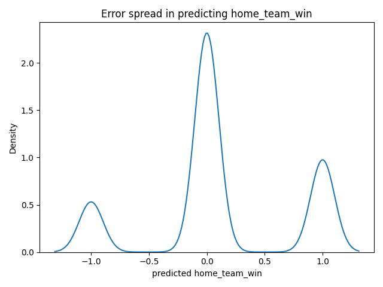

```python
@run
@cached_chart()
def logistic_error_spread():
    g = sns.kdeplot(diffs)
    plt.title(f"Error spread in predicting home_team_win")
    plt.xlabel("predicted home_team_win")
    return g
```

```python
predictions = pd.DataFrame(
    {
        "actual": y_test,
        "predicted": predicted_unscaled,
    }
)
```

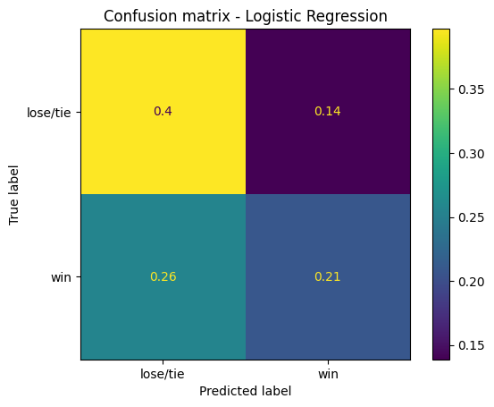

```python
ConfusionMatrixDisplay.from_predictions(
    predictions["actual"],
    predictions["predicted"],
    labels=[0, 1],
    display_labels=["lose/tie", "win"],
    normalize="all",
)
plt.title("Confusion matrix - Logistic Regression")
__
```

```python
score
```

```
0.6088886258728844
```

This score is almost identical to the previous (without AutoFeat for feature engineering).. the true positives have improved a bit (5 percentual points), but nothing beyond this...

## Predicting results using PCA (bonus)

```python
match_aggs.df()
```

|  | match_api_id | overall_rating_away_defense | overall_rating_away_forward | overall_rating_away_goalkeeper | overall_rating_away_midfielder | overall_rating_home_defense | overall_rating_home_forward | overall_rating_home_goalkeeper | overall_rating_home_midfielder | potential_away_defense | ... | count_away_defense | count_away_forward | count_away_goalkeeper | count_away_midfielder | count_home_defense | count_home_forward | count_home_goalkeeper | count_home_midfielder | home_team_goal_advantage | home_team_win |
| --- | --- | --- | --- | --- | --- | --- | --- | --- | --- | --- | --- | --- | --- | --- | --- | --- | --- | --- | --- | --- | --- |
| 0 | 1002982 | 285 | 147 | 71 | 289 | 295 | 143 | 79 | 281 | 302 | ... | 4 | 2 | 1 | 4 | 4 | 2 | 1 | 4 | 0 | 0 |
| 1 | 1005014 | 252 | 51 | 70 | 329 | 259 | 75 | 68 | 342 | 275 | ... | 4 | 1 | 1 | 5 | 4 | 1 | 1 | 5 | 2 | 1 |
| 2 | 1005015 | 268 | 131 | 66 | 204 | 203 | 132 | 66 | 270 | 290 | ... | 4 | 2 | 1 | 4 | 4 | 2 | 1 | 4 | 0 | 0 |
| 3 | 1005016 | 254 | 61 | 66 | 293 | 237 | 60 | 63 | 318 | 268 | ... | 4 | 1 | 1 | 5 | 4 | 1 | 1 | 5 | 0 | 0 |
| 4 | 1005017 | 250 | 126 | 62 | 254 | 248 | 124 | 62 | 196 | 264 | ... | 4 | 2 | 1 | 4 | 4 | 2 | 1 | 4 | -3 | 0 |
| ... | ... | ... | ... | ... | ... | ... | ... | ... | ... | ... | ... | ... | ... | ... | ... | ... | ... | ... | ... | ... | ... |
| 24135 | 954551 | 128 | 59 | 66 | 328 | 268 | 150 | 75 | 274 | 140 | ... | 4 | 1 | 1 | 5 | 4 | 2 | 1 | 4 | 3 | 1 |
| 24136 | 954552 | 196 | 66 | 57 | 281 | 179 | 120 | 0 | 176 | 217 | ... | 4 | 1 | 1 | 5 | 4 | 3 | 1 | 3 | 2 | 1 |
| 24137 | 954553 | 236 | 125 | 66 | 241 | 253 | 119 | 58 | 249 | 274 | ... | 4 | 2 | 1 | 4 | 4 | 2 | 1 | 4 | 0 | 0 |
| 24138 | 954554 | 234 | 59 | 62 | 318 | 263 | 63 | 71 | 334 | 251 | ... | 4 | 1 | 1 | 5 | 4 | 1 | 1 | 5 | 2 | 1 |
| 24139 | 954555 | 218 | 65 | 62 | 287 | 244 | 131 | 72 | 261 | 252 | ... | 4 | 1 | 1 | 5 | 4 | 2 | 1 | 4 | 1 | 1 |

24140 rows × 307 columns

```python
warnings.filterwarnings("ignore", category=UserWarning)
warnings.filterwarnings("ignore", category=DataConversionWarning)
warnings.filterwarnings("ignore", category=RuntimeWarning)
```

```python
def compare_scores(n: int):
    pca_df = match_aggs.df()
    pca_df = pca_df.drop(columns="home_team_win")

    y_pla_df = pca_df[["home_team_goal_advantage"]]
    x_pca_df = pca_df.drop(columns=["home_team_goal_advantage"])

    X_train, X_test, y_train, y_test = train_test_split(
        x_pca_df, y_pla_df, test_size=0.3, random_state=1
    )

    scaler = StandardScaler()
    X_train = scaler.fit_transform(X_train, y_train)
    X_test = scaler.fit_transform(X_test)

    pca = PCA(n_components=n)
    X_train_pca = pca.fit_transform(X_train)
    X_test_pca = pca.transform(X_test)

    kbest = SelectKBest(k=n)
    X_train_kbest = kbest.fit_transform(X_train, y_train)
    X_test_kbest = kbest.transform(X_test)

    lr_pca = LogisticRegression()
    lr_kbest = LogisticRegression()

    lr_pca.fit(X_train_pca, y_train)
    lr_kbest.fit(X_train_kbest, y_train)

    score_pca = lr_pca.score(X_test_pca, y_test)
    score_kb = lr_kbest.score(X_test_kbest, y_test)
    print(n, score_pca, score_kb)
    return score_pca, score_kb
```

```python
scores = {i: compare_scores(i) for i in range(1, 300, 25)}
```

```
1 0.24606462303231152 0.24772162386081192
26 0.2659486329743165 0.25048329190831264
51 0.26208229770781555 0.25296879315106324
76 0.2613918806959403 0.2571112952223143
101 0.2642916321458161 0.2597348798674399
126 0.25738746202706436 0.26001104667219
151 0.2604252968793151 0.2531068765534383
176 0.25504004418668874 0.2515879591273129
201 0.25545429439381384 0.24855012427506215
226 0.2524164595415631 0.247997790665562
251 0.24426953880143606 0.2459265396299365
276 0.24385528859431096 0.2459265396299365
```

```
Loading from cache [./cached/charts/pca_kbest_scores.png]
```

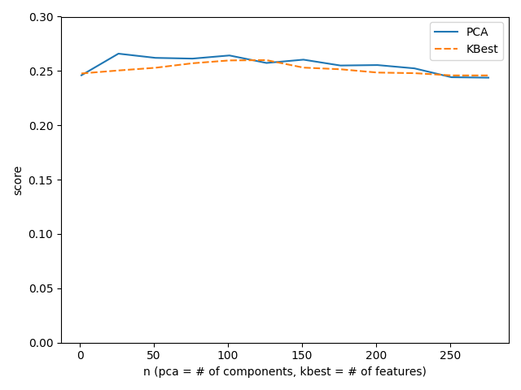

```python
@run
@cached_chart()
def pca_kbest_scores():
    g = sns.lineplot(data=pd.DataFrame(scores, index=["PCA", "KBest"]).T)
    plt.xlabel("n (pca = # of components, kbest = # of features)")
    plt.ylabel("score")
    plt.ylim(0, 0.30)
    return g
```

It seems that the performance of the models do not improve by a lot, even if we add lots of features.

We do see a small downgrade in performance once we cross PCA with more than 100 components, and Kbest with more than 125 features. This drop is very likely caused by overfitting.

# Conclusions

This analysis encompasses the ultimate-25k-matches-football dataset https://www.kaggle.com/datasets/prajitdatta/ultimate-25k-matches-football-database-european

- The data seems roughly clean, despite having a large divide between the matches in terms of data richness. Half the matches are missing detailed data.
- The analysis shows the importance of trying different approaches to created various models for our data.
  - Some methods (like predicting goal difference) do not perform well, while others (predicting win/no win) show much more promise and outperform the first by an entire order of magnitude.
- One of the requirements/constraints was to build models only using linear machine learning models (linea/logistic regression).
- It also includes 2 bonus implementations (using AutoFeat and Principal Component Analysis) to explore options beyond linear models.
  - These models did not noticeably improve the performance of Logistic regression

# Lessons Learned

These are some interesting things I've learned that I wanted to share

## On Computational Performance

While some of the tools used in this analysis are absolute time-savers, I did notice growing worried with how long it took to perform some operations (eg. using `ydata_profiling` to get a quick understanding of the raw data)

Note: For this example I will use `ydata_profiling` but these also apply to other tools/expensive computations:

I noticed that even though jupyter is configured to use up to 8 cores (`threading.active_count()`), none of the cores were being fully utilized, so I tried to look for ways to speed up these computations:

1. I first tried reducing the number of steps used (disabling `interactions`, then disabling `correlations`, then using the `minimal=True` config, then using a small sample of the data: a few 1000s of rows).
   - Did it work?
     - ✅ Some yes. These did work really well, but I wanted to find out how to get the best proverbial bang for the computational buck, and I was also worried that these might omit some important insights.
2. I then looked for ways to fully utilize that hardware available. This brought new questions:
   - Is there a way to configure jupyter/kernel/IPython/anaconda/python interpreter/runtime engine/virtual machine/threading/OS cpu affinity/...?
   - Is there any way to increase the resources allocated? or to remove limits, so that more cores can be used? or to allow those cores to boost up to 100% utilization?
   - Did it work?
     - ❌ Not really. I couldn't find any way to configure the Python interpreter to use a different number of CPU Cores.
     - The options for multithreading require tools built from the ground up, and while ydata_profiling seems to use multithreading in some of its calculations (e.g when `%%time` shows that the CPU time is much greater than the Wall time), I don't believe there are low hanging fruit in there.
3. Is there a way to precompile some code?
   - Numpy is way faster... because it is not python code... so: Is there any way to use a just-in-time compiler to pre-compile part of my code (and, through cascading, the code in the libraries that I will be calling), so that it runs faster?
   - What about Numba and its JIT compiler?
   - Did it work?
     - ❌ No. Numba cannot really optimize code from other imported libraries. It could be used for code that I developed myself, but I cannot simply wrap a call to a library and expect it to compile everything down the call stack.
4. Is there a way to split up a single call to an external library into various streams (so it can be parallelized)?
   - While it would be possible to split a dataframe into various parts, and create threads for each of those parts, it's also far from ideal.
   - If we split the dataframe by rows, this is just the same as doing a `.sample(n)` various times.
   - If we split it by columns, this defeats the purpose of the more expensive computations (finding correlations between columns), as some of those correlations will never be calculated. eg. if we have a dataframe with 40 columns and we split it into 4 parts with 10 columns, we're only getting (400=10x10x4) correlations scores instead of the original 1600 = $40 * 40$

While this was a great opportunity to learn more about performance optimization in Python most of the value could be extracted with little cost. In the end, I opted to use:

- small samples (a few 1000s of rows)
- include `interactions` but not `correlations`.

These are the durations of various runs:

```
none: few seconds
just interactions: 2m55 (CPU), 0m46sec wall time
just correlations: 4min (CPU), 4m02sec min wall time
both: not even gonna try it. Too long!
```

I might explore Numba in the future, if I ever need to speed up code that I have written myself and where such an investment results in a noticeable boost that justifies it.

## On Perceived Performance

While I couldn't really boost the true performance of the computations, I could greatly improve the [perceived performance](https://uxdesign.cc/the-importance-of-perceived-performance-for-a-successful-user-experience-ac2f428887f9) for me and any readers that wanted to explore the notebook.

### Using Caching to store/retrieve precomputed data.

In order to not have to rerun the notebook from scratch every time, I created a small caching utility that can use serialization to store precomputed data, and to retrieve it at a later date (future runs).

This means that rerunning the entire notebook is a lot faster, since some of the data has already been stored, and reading from disk+rendering is very cheap. The utilities also provide flags to force reruns (for assurance that the stored data is not manipulated and can be recreated at any time, if one is willing to wait for expensive computations to finish).

This library has been created and evolved over the last few projects and it currently supports:

1. charts: matplotlib, sns
2. data: pd DataFrames, np arrays
3. ydata profile reports
4. any arbitrary objects that support pickling

## On using pipelines for data operations

Ever since I discovered that talk at [PyData Eindhoven 2019, by Vincent D. Warmerdam](https://www.youtube.com/watch?v=yXGCKqo5cEY&t=1110s), I have been wanting to try these.

### The PROs

They seemed to have lots of benefits:

- PURPOSE: allowing me to explain transformations as individual steps (thus, requiring a meaningful name)
- SEPARATION OF CONCERNS: allowing me to split up core components of the cleaning steps:
  - the WHAT: being encoded in the method name + parameters
  - the HOW: (boring details, in most cases): hidden away into a module/function
  - the WHY: explained in the markdown cells
- METADATA: allowing me to store metadata and returning secondary results
- PRACTICE: allowing me to practice advanced pythonic data structures/algorithms
- ...

### The CONs

But they also had some drawbacks:

- CONTEXT: It was difficult to sharing context with other people (eg. when showing it to other people/peers in my batch)
  - the opacity of the pipeline, and the lack of familiarity with *my specific implementation* meant that other people were initially confused as to what this is supposed to be doing, or how it worked.
- DATA: The initial inertia meant that I was considering using pipelines for ALL non-trivial operations on dataframes.
  - This worked quite well for data cleaning/visualization/EDA/...
  - This worked not so well for creating models

### Why roll my own, from scratch?

(why reinvent the wheel)

(why reinvent the wheel, without googling what a wheel is?)

Short answer: I really wanted to try it out, as a learning exercise, even if it turned out to be a terrible choice. Most of the issues with pipelines at any scale will likely pop up at a small scale as well, and this provided a good (realistic) environment to explore this.

Since I decided to build my own implementation from scratch (without doing further research into available options), there were several tradeoffs:

- `+` No chance of copying/plagiarising existing functionality
- `+` No chance of including code without understanding exactly why it exists? Everything I coded actually responds to a specific need I had at some point
- `+` It also allowed me to understand the tradeoffs that some of these design decisions carry with them (how should I handle "steps" that don't mutate the data, but that generate/train a model? is the pipeline still the correct structure for this? if not, why not?)
- `-` Actively not looking at options available means that, it's likely that I missed some pattern that would have been super useful 🤷‍♂️ oh well...

Fundamentally, it was a very useful learning exercise, and I haven't decided whether I will keep using them in the future.

In general, they seem to help with data transformations, but the rest of the operations (modelling, etc...) doesn't really fit this paradigm.

PS: Now that I have finished my project I did google about Pipelines and noticed that sklearn seems to have the exact same structure builtin using transformers. It seems most of the opeartions I created for my data manipulations could have been done using sklearn's `FunctionTransformer` :)